# EndPoints hormonal treatments - CTL04

Date: July 21, 2025

## Purpose

Approaches

**Basic DEA vs DMSO**

- Overlap of genes modulated by Agonist treatment vs DMSO (split in up-reg and down-reg) - section 3
- Overlap of genes modulated by Inhibitor treatment vs DMSO (split in up-reg and down-reg) - section 4
- Overlap of up-regulated genes induced by treatment vs DMSO (either agonist or antagonist) - section 5
- Overlap of down-regulated genes induced by treatment vs DMSO (either agonist or antagonist) - section 6

**Basic DEA Agonist vs Inhibitor**

- Overlap of genes modulated by Agonist treatment vs Inhibitor (split in up-reg and down-reg) - section 7

Analyses are performed for all pathways or a selected subset (estrogen, retionic, thyroid, liverX).

# 1. Environment SetUp

```r
knitr::opts_chunk$set(echo = TRUE, warning=FALSE, collapse = TRUE)
```

```r
library(tidyr)
library(dplyr)
```

```r
library(ggplot2)
library(GeneOverlap)

OutputFolder <- params$OutputFolder
```

# 2. Data Upload

```r
DEA <- readRDS(paste0(params$InputFolder, 'DEARes.rds'))
```

# 3. Comparison across pathways: treatment with Agonist

## 3.1 Perform Overlap

```r
DEGs_Agonist <- list(

  Thyr_Ag_Up= row.names(DEA$Thyr$Agonist$DEGs[DEA$Thyr$Agonist$DEGs$log2FoldChange > 0, ]),
  Thyr_Ag_Down= row.names(DEA$Thyr$Agonist$DEGs[DEA$Thyr$Agonist$DEGs$log2FoldChange < 0, ]),

  Ret_Ag_Up= row.names(DEA$Ret$Agonist$DEGs[DEA$Ret$Agonist$DEGs$log2FoldChange > 0, ]),
  Ret_Ag_Down= row.names(DEA$Ret$Agonist$DEGs[DEA$Ret$Agonist$DEGs$log2FoldChange < 0, ]),

  Estr_Ag_Up= row.names(DEA$Estr$Agonist$DEGs[DEA$Estr$Agonist$DEGs$log2FoldChange > 0, ]),
  Estr_Ag_Down= row.names(DEA$Estr$Agonist$DEGs[DEA$Estr$Agonist$DEGs$log2FoldChange < 0, ]),

  Andr_Ag_Up= row.names(DEA$Andr$Agonist$DEGs[DEA$Andr$Agonist$DEGs$log2FoldChange > 0, ]),
  Andr_Ag_Down= row.names(DEA$Andr$Agonist$DEGs[DEA$Andr$Agonist$DEGs$log2FoldChange < 0, ]),

  GC_Ag_Up= row.names(DEA$GC$Agonist$DEGs[DEA$GC$Agonist$DEGs$log2FoldChange > 0, ]),
  GC_Ag_Down= row.names(DEA$GC$Agonist$DEGs[DEA$GC$Agonist$DEGs$log2FoldChange < 0, ]),

  LivX_Ag_Up= row.names(DEA$LivX$Agonist$DEGs[DEA$LivX$Agonist$DEGs$log2FoldChange > 0, ]),
  LivX_Ag_Down= row.names(DEA$LivX$Agonist$DEGs[DEA$LivX$Agonist$DEGs$log2FoldChange < 0, ]),

  AhHyd_Ag_Up= row.names(DEA$AhHyd$Agonist$DEGs[DEA$AhHyd$Agonist$DEGs$log2FoldChange > 0, ]),
  AhHyd_Ag_Down= row.names(DEA$AhHyd$Agonist$DEGs[DEA$AhHyd$Agonist$DEGs$log2FoldChange < 0, ])

            )
```

```r
Universe <- row.names(DEA$Ret$Agonist$Res) %>% unique()
length(Universe)
```

```
## [1] 14305
```

```r
OvObj <- newGOM(DEGs_Agonist, DEGs_Agonist, genome.size=length(Universe))
print(OvObj)
## A GeneOverlapMatrix object:
## ###### Intersection ######
##               Thyr_Ag_Up Thyr_Ag_Down Ret_Ag_Up Ret_Ag_Down Estr_Ag_Up
## Thyr_Ag_Up            78            0        48          17          1
## Thyr_Ag_Down           0           69        11          36          0
## Ret_Ag_Up             48           11      1861           0          1
## Ret_Ag_Down           17           36         0        1108          0
## Estr_Ag_Up             1            0         1           0          1
## Estr_Ag_Down           0            2         1           0          0
## Andr_Ag_Up             3            3        58           7          1
## Andr_Ag_Down           0            2        16           5          0
## GC_Ag_Up               1            0         4           0          1
## GC_Ag_Down             0            2         4           1          0
## LivX_Ag_Up             1            0         2           0          1
## LivX_Ag_Down           1            1         4           0          0
## AhHyd_Ag_Up            2            1         2           9          1
## AhHyd_Ag_Down          2            5        30          12          0
##               Estr_Ag_Down Andr_Ag_Up Andr_Ag_Down GC_Ag_Up GC_Ag_Down
## Thyr_Ag_Up               0          3            0        1          0
## Thyr_Ag_Down             2          3            2        0          2
## Ret_Ag_Up                1         58           16        4          4
## Ret_Ag_Down              0          7            5        0          1
## Estr_Ag_Up               0          1            0        1          0
## Estr_Ag_Down             3          2            0        0          1
## Andr_Ag_Up               2        197            0        3          5
## Andr_Ag_Down             0          0           45        0          1
## GC_Ag_Up                 0          3            0        6          0
## GC_Ag_Down               1          5            1        0         13
## LivX_Ag_Up               0          1            0        1          0
## LivX_Ag_Down             1          2            0        0          3
## AhHyd_Ag_Up              0          3            0        1          0
## AhHyd_Ag_Down            0          0            2        0          0
##               LivX_Ag_Up LivX_Ag_Down AhHyd_Ag_Up AhHyd_Ag_Down
## Thyr_Ag_Up             1            1           2             2
## Thyr_Ag_Down           0            1           1             5
## Ret_Ag_Up              2            4           2            30
## Ret_Ag_Down            0            0           9            12
## Estr_Ag_Up             1            0           1             0
## Estr_Ag_Down           0            1           0             0
## Andr_Ag_Up             1            2           3             0
## Andr_Ag_Down           0            0           0             2
## GC_Ag_Up               1            0           1             0
## GC_Ag_Down             0            3           0             0
## LivX_Ag_Up            10            0           1             0
## LivX_Ag_Down           0            6           0             0
## AhHyd_Ag_Up            1            0          20             0
## AhHyd_Ag_Down          0            0           0            56
## ###### P-value ######
##                  Thyr_Ag_Up  Thyr_Ag_Down    Ret_Ag_Up  Ret_Ag_Down
## Thyr_Ag_Up    1.040621e-209  1.000000e+00 1.137907e-23 7.805123e-05
## Thyr_Ag_Down   1.000000e+00 3.766883e-189 2.819577e-01 2.579072e-22
## Ret_Ag_Up      1.137907e-23  2.819577e-01 0.000000e+00 1.000000e+00
## Ret_Ag_Down    7.805123e-05  2.579072e-22 1.000000e+00 0.000000e+00
## Estr_Ag_Up     5.452639e-03  1.000000e+00 1.300944e-01 1.000000e+00
## Estr_Ag_Down   1.000000e+00  6.857653e-05 3.417319e-01 1.000000e+00
## Andr_Ag_Up     9.265938e-02  6.965485e-02 8.016126e-10 9.951476e-01
## Andr_Ag_Down   1.000000e+00  1.986370e-02 9.868927e-05 2.675348e-01
## GC_Ag_Up       3.227866e-02  1.000000e+00 3.442533e-03 1.000000e+00
## GC_Ag_Down     1.000000e+00  1.728186e-03 7.772264e-02 6.495414e-01
## LivX_Ag_Up     5.322409e-02  1.000000e+00 3.807545e-01 1.000000e+00
## LivX_Ag_Down   3.227866e-02  2.859911e-02 3.442533e-03 1.000000e+00
## AhHyd_Ag_Up    5.232939e-03  9.223306e-02 7.544395e-01 7.453704e-06
## AhHyd_Ag_Down  3.739553e-02  7.114372e-06 4.642748e-13 1.007141e-03
##                 Estr_Ag_Up Estr_Ag_Down   Andr_Ag_Up  Andr_Ag_Down     GC_Ag_Up
## Thyr_Ag_Up    5.452639e-03 1.000000e+00 9.265938e-02  1.000000e+00 3.227866e-02
## Thyr_Ag_Down  1.000000e+00 6.857653e-05 6.965485e-02  1.986370e-02 1.000000e+00
## Ret_Ag_Up     1.300944e-01 3.417319e-01 8.016126e-10  9.868927e-05 3.442533e-03
## Ret_Ag_Down   1.000000e+00 1.000000e+00 9.951476e-01  2.675348e-01 1.000000e+00
## Estr_Ag_Up    6.990563e-05 1.000000e+00 1.377141e-02  1.000000e+00 4.194338e-04
## Estr_Ag_Down  1.000000e+00 2.050117e-12 5.609612e-04  1.000000e+00 1.000000e+00
## Andr_Ag_Up    1.377141e-02 5.609612e-04 0.000000e+00  1.000000e+00 4.989996e-05
## Andr_Ag_Down  1.000000e+00 1.000000e+00 1.000000e+00 1.291057e-131 1.000000e+00
## GC_Ag_Up      4.194338e-04 1.000000e+00 4.989996e-05  1.000000e+00 8.411255e-23
## GC_Ag_Down    1.000000e+00 2.724033e-03 5.539904e-07  4.014828e-02 1.000000e+00
## LivX_Ag_Up    6.990563e-04 1.000000e+00 1.295240e-01  1.000000e+00 4.187745e-03
## LivX_Ag_Down  1.000000e+00 1.257861e-03 2.729185e-03  1.000000e+00 1.000000e+00
## AhHyd_Ag_Up   1.398113e-03 1.000000e+00 2.467071e-03  1.000000e+00 8.360865e-03
## AhHyd_Ag_Down 1.000000e+00 1.000000e+00 1.000000e+00  1.337955e-02 1.000000e+00
##                 GC_Ag_Down   LivX_Ag_Up LivX_Ag_Down  AhHyd_Ag_Up AhHyd_Ag_Down
## Thyr_Ag_Up    1.000000e+00 5.322409e-02 3.227866e-02 5.232939e-03  3.739553e-02
## Thyr_Ag_Down  1.728186e-03 1.000000e+00 2.859911e-02 9.223306e-02  7.114372e-06
## Ret_Ag_Up     7.772264e-02 3.807545e-01 3.442533e-03 7.544395e-01  4.642748e-13
## Ret_Ag_Down   6.495414e-01 1.000000e+00 1.000000e+00 7.453704e-06  1.007141e-03
## Estr_Ag_Up    1.000000e+00 6.990563e-04 1.000000e+00 1.398113e-03  1.000000e+00
## Estr_Ag_Down  2.724033e-03 1.000000e+00 1.257861e-03 1.000000e+00  1.000000e+00
## Andr_Ag_Up    5.539904e-07 1.295240e-01 2.729185e-03 2.467071e-03  1.000000e+00
## Andr_Ag_Down  4.014828e-02 1.000000e+00 1.000000e+00 1.000000e+00  1.337955e-02
## GC_Ag_Up      1.000000e+00 4.187745e-03 1.000000e+00 8.360865e-03  1.000000e+00
## GC_Ag_Down    5.960832e-45 1.000000e+00 1.170823e-08 1.000000e+00  1.000000e+00
## LivX_Ag_Up    1.000000e+00 1.014497e-35 1.000000e+00 1.389784e-02  1.000000e+00
## LivX_Ag_Down  1.170823e-08 1.000000e+00 8.411255e-23 1.000000e+00  1.000000e+00
## AhHyd_Ag_Up   1.000000e+00 1.389784e-02 1.000000e+00 1.914866e-65  1.000000e+00
## AhHyd_Ag_Down 1.000000e+00 1.000000e+00 1.000000e+00 1.000000e+00 1.553685e-158
## ###### Odds Ratio ######
##               Thyr_Ag_Up Thyr_Ag_Down  Ret_Ag_Up Ret_Ag_Down Estr_Ag_Up
## Thyr_Ag_Up           Inf     0.000000 10.9510459   3.3550283        Inf
## Thyr_Ag_Down    0.000000          Inf  1.2697431  13.3903265          0
## Ret_Ag_Up      10.951046     1.269743        Inf   0.0000000        Inf
## Ret_Ag_Down     3.355028    13.390327  0.0000000         Inf          0
## Estr_Ag_Up           Inf     0.000000        Inf   0.0000000        Inf
## Estr_Ag_Down    0.000000   419.587900  3.3442545   0.0000000          0
## Andr_Ag_Up      2.892986     3.289530  2.8474388   0.4352635        Inf
## Andr_Ag_Down    0.000000     9.846678  3.7124461   1.4909839          0
## GC_Ag_Up       36.835016     0.000000 13.3957228   0.0000000        Inf
## GC_Ag_Down      0.000000    38.505367  2.9758029   0.9925479          0
## LivX_Ag_Up     20.501898     0.000000  1.6723256   0.0000000        Inf
## LivX_Ag_Down   36.835016    41.741898 13.3957228   0.0000000          0
## AhHyd_Ag_Up    20.736391    10.997978  0.7427073   9.8136457        Inf
## AhHyd_Ag_Down   6.902948    21.699494  7.8218662   3.2725273          0
##               Estr_Ag_Down  Andr_Ag_Up Andr_Ag_Down  GC_Ag_Up   GC_Ag_Down
## Thyr_Ag_Up        0.000000   2.8929860     0.000000  36.83502    0.0000000
## Thyr_Ag_Down    419.587900   3.2895301     9.846678   0.00000   38.5053671
## Ret_Ag_Up         3.344255   2.8474388     3.712446  13.39572    2.9758029
## Ret_Ag_Down       0.000000   0.4352635     1.490984   0.00000    0.9925479
## Estr_Ag_Up        0.000000         Inf     0.000000       Inf    0.0000000
## Estr_Ag_Down           Inf 143.8041372     0.000000   0.00000  572.4231226
## Andr_Ag_Up      143.804137         Inf     0.000000  72.58376   45.8103110
## Andr_Ag_Down      0.000000   0.0000000          Inf   0.00000   26.9525489
## GC_Ag_Up          0.000000  72.5837635     0.000000       Inf    0.0000000
## GC_Ag_Down      572.423123  45.8103110    26.952549   0.00000          Inf
## LivX_Ag_Up        0.000000   7.9892731     0.000000 315.81514    0.0000000
## LivX_Ag_Down   1380.290241  36.1085325     0.000000   0.00000 1338.8541918
## AhHyd_Ag_Up       0.000000  12.8099630     0.000000 148.99012    0.0000000
## AhHyd_Ag_Down     0.000000   0.0000000    12.226893   0.00000    0.0000000
##               LivX_Ag_Up LivX_Ag_Down AhHyd_Ag_Up AhHyd_Ag_Down
## Thyr_Ag_Up     20.501898     36.83502  20.7363905      6.902948
## Thyr_Ag_Down    0.000000     41.74190  10.9979777     21.699494
## Ret_Ag_Up       1.672326     13.39572   0.7427073      7.821866
## Ret_Ag_Down     0.000000      0.00000   9.8136457      3.272527
## Estr_Ag_Up           Inf      0.00000         Inf      0.000000
## Estr_Ag_Down    0.000000   1380.29024   0.0000000      0.000000
## Andr_Ag_Up      7.989273     36.10853  12.8099630      0.000000
## Andr_Ag_Down    0.000000      0.00000   0.0000000     12.226893
## GC_Ag_Up      315.815143      0.00000 148.9901154      0.000000
## GC_Ag_Down      0.000000   1338.85419   0.0000000      0.000000
## LivX_Ag_Up           Inf      0.00000  83.1198722      0.000000
## LivX_Ag_Down    0.000000          Inf   0.0000000      0.000000
## AhHyd_Ag_Up    83.119872      0.00000         Inf      0.000000
## AhHyd_Ag_Down   0.000000      0.00000   0.0000000           Inf
## ###### Jaccard Index ######
##               Thyr_Ag_Up Thyr_Ag_Down    Ret_Ag_Up  Ret_Ag_Down   Estr_Ag_Up
## Thyr_Ag_Up    1.00000000  0.000000000 0.0253833950 0.0145423439 0.0128205128
## Thyr_Ag_Down  0.00000000  1.000000000 0.0057321522 0.0315512708 0.0000000000
## Ret_Ag_Up     0.02538340  0.005732152 1.0000000000 0.0000000000 0.0005373455
## Ret_Ag_Down   0.01454234  0.031551271 0.0000000000 1.0000000000 0.0000000000
## Estr_Ag_Up    0.01282051  0.000000000 0.0005373455 0.0000000000 1.0000000000
## Estr_Ag_Down  0.00000000  0.028571429 0.0005367687 0.0000000000 0.0000000000
## Andr_Ag_Up    0.01102941  0.011406844 0.0290000000 0.0053929122 0.0050761421
## Andr_Ag_Down  0.00000000  0.017857143 0.0084656085 0.0043554007 0.0000000000
## GC_Ag_Up      0.01204819  0.000000000 0.0021470746 0.0000000000 0.1666666667
## GC_Ag_Down    0.00000000  0.025000000 0.0021390374 0.0008928571 0.0000000000
## LivX_Ag_Up    0.01149425  0.000000000 0.0010700910 0.0000000000 0.1000000000
## LivX_Ag_Down  0.01204819  0.013513514 0.0021470746 0.0000000000 0.0000000000
## AhHyd_Ag_Up   0.02083333  0.011363636 0.0010643960 0.0080428954 0.0500000000
## AhHyd_Ag_Down 0.01515152  0.041666667 0.0158982512 0.0104166667 0.0000000000
##               Estr_Ag_Down  Andr_Ag_Up Andr_Ag_Down    GC_Ag_Up   GC_Ag_Down
## Thyr_Ag_Up    0.0000000000 0.011029412  0.000000000 0.012048193 0.0000000000
## Thyr_Ag_Down  0.0285714286 0.011406844  0.017857143 0.000000000 0.0250000000
## Ret_Ag_Up     0.0005367687 0.029000000  0.008465608 0.002147075 0.0021390374
## Ret_Ag_Down   0.0000000000 0.005392912  0.004355401 0.000000000 0.0008928571
## Estr_Ag_Up    0.0000000000 0.005076142  0.000000000 0.166666667 0.0000000000
## Estr_Ag_Down  1.0000000000 0.010101010  0.000000000 0.000000000 0.0666666667
```

```r
## Andr_Ag_Up    0.0101010101 1.000000000  0.000000000 0.015000000 0.0243902439
## Andr_Ag_Down  0.0000000000 0.000000000  1.000000000 0.000000000 0.0175438596
## GC_Ag_Up      0.0000000000 0.015000000  0.000000000 1.000000000 0.0000000000
## GC_Ag_Down    0.0666666667 0.024390244  0.017543860 0.000000000 1.0000000000
## LivX_Ag_Up    0.0000000000 0.004854369  0.000000000 0.066666667 0.0000000000
## LivX_Ag_Down  0.1250000000 0.009950249  0.000000000 0.000000000 0.1875000000
## AhHyd_Ag_Up   0.0000000000 0.014018692  0.000000000 0.040000000 0.0000000000
## AhHyd_Ag_Down 0.0000000000 0.000000000  0.020202020 0.000000000 0.0000000000
##                LivX_Ag_Up LivX_Ag_Down AhHyd_Ag_Up AhHyd_Ag_Down
## Thyr_Ag_Up    0.011494253  0.012048193 0.020833333    0.01515152
## Thyr_Ag_Down  0.000000000  0.013513514 0.011363636    0.04166667
## Ret_Ag_Up     0.001070091  0.002147075 0.001064396    0.01589825
## Ret_Ag_Down   0.000000000  0.000000000 0.008042895    0.01041667
## Estr_Ag_Up    0.100000000  0.000000000 0.050000000    0.00000000
## Estr_Ag_Down  0.000000000  0.125000000 0.000000000    0.00000000
## Andr_Ag_Up    0.004854369  0.009950249 0.014018692    0.00000000
## Andr_Ag_Down  0.000000000  0.000000000 0.000000000    0.02020202
## GC_Ag_Up      0.066666667  0.000000000 0.040000000    0.00000000
## GC_Ag_Down    0.000000000  0.187500000 0.000000000    0.00000000
## LivX_Ag_Up    1.000000000  0.000000000 0.034482759    0.00000000
## LivX_Ag_Down  0.000000000  1.000000000 0.000000000    0.00000000
## AhHyd_Ag_Up   0.034482759  0.000000000 1.000000000    0.00000000
## AhHyd_Ag_Down 0.000000000  0.000000000 0.000000000    1.00000000
```

```r
getMatrix(OvObj, name='intersection')
```

```
##               Thyr_Ag_Up Thyr_Ag_Down Ret_Ag_Up Ret_Ag_Down Estr_Ag_Up
## Thyr_Ag_Up            78            0        48          17          1
## Thyr_Ag_Down           0           69        11          36          0
## Ret_Ag_Up             48           11      1861           0          1
## Ret_Ag_Down           17           36         0        1108          0
## Estr_Ag_Up             1            0         1           0          1
## Estr_Ag_Down           0            2         1           0          0
## Andr_Ag_Up             3            3        58           7          1
## Andr_Ag_Down           0            2        16           5          0
## GC_Ag_Up               1            0         4           0          1
## GC_Ag_Down             0            2         4           1          0
## LivX_Ag_Up             1            0         2           0          1
## LivX_Ag_Down           1            1         4           0          0
## AhHyd_Ag_Up            2            1         2           9          1
## AhHyd_Ag_Down          2            5        30          12          0
##               Estr_Ag_Down Andr_Ag_Up Andr_Ag_Down GC_Ag_Up GC_Ag_Down
## Thyr_Ag_Up               0          3            0        1          0
## Thyr_Ag_Down             2          3            2        0          2
## Ret_Ag_Up                1         58           16        4          4
## Ret_Ag_Down              0          7            5        0          1
## Estr_Ag_Up               0          1            0        1          0
## Estr_Ag_Down             3          2            0        0          1
## Andr_Ag_Up               2        197            0        3          5
## Andr_Ag_Down             0          0           45        0          1
## GC_Ag_Up                 0          3            0        6          0
## GC_Ag_Down               1          5            1        0         13
## LivX_Ag_Up               0          1            0        1          0
## LivX_Ag_Down             1          2            0        0          3
## AhHyd_Ag_Up              0          3            0        1          0
## AhHyd_Ag_Down            0          0            2        0          0
##               LivX_Ag_Up LivX_Ag_Down AhHyd_Ag_Up AhHyd_Ag_Down
## Thyr_Ag_Up             1            1           2             2
## Thyr_Ag_Down           0            1           1             5
## Ret_Ag_Up              2            4           2            30
## Ret_Ag_Down            0            0           9            12
## Estr_Ag_Up             1            0           1             0
## Estr_Ag_Down           0            1           0             0
## Andr_Ag_Up             1            2           3             0
## Andr_Ag_Down           0            0           0             2
## GC_Ag_Up               1            0           1             0
## GC_Ag_Down             0            3           0             0
## LivX_Ag_Up            10            0           1             0
## LivX_Ag_Down           0            6           0             0
## AhHyd_Ag_Up            1            0          20             0
## AhHyd_Ag_Down          0            0           0            56
```

```r
getMatrix(OvObj, name='pval')
```

```
##                  Thyr_Ag_Up  Thyr_Ag_Down    Ret_Ag_Up  Ret_Ag_Down
## Thyr_Ag_Up    1.040621e-209  1.000000e+00 1.137907e-23 7.805123e-05
## Thyr_Ag_Down   1.000000e+00 3.766883e-189 2.819577e-01 2.579072e-22
## Ret_Ag_Up      1.137907e-23  2.819577e-01 0.000000e+00 1.000000e+00
## Ret_Ag_Down    7.805123e-05  2.579072e-22 1.000000e+00 0.000000e+00
## Estr_Ag_Up     5.452639e-03  1.000000e+00 1.300944e-01 1.000000e+00
## Estr_Ag_Down   1.000000e+00  6.857653e-05 3.417319e-01 1.000000e+00
## Andr_Ag_Up     9.265938e-02  6.965485e-02 8.016126e-10 9.951476e-01
## Andr_Ag_Down   1.000000e+00  1.986370e-02 9.868927e-05 2.675348e-01
## GC_Ag_Up       3.227866e-02  1.000000e+00 3.442533e-03 1.000000e+00
## GC_Ag_Down     1.000000e+00  1.728186e-03 7.772264e-02 6.495414e-01
## LivX_Ag_Up     5.322409e-02  1.000000e+00 3.807545e-01 1.000000e+00
## LivX_Ag_Down   3.227866e-02  2.859911e-02 3.442533e-03 1.000000e+00
## AhHyd_Ag_Up    5.232939e-03  9.223306e-02 7.544395e-01 7.453704e-06
## AhHyd_Ag_Down  3.739553e-02  7.114372e-06 4.642748e-13 1.007141e-03
##                 Estr_Ag_Up Estr_Ag_Down   Andr_Ag_Up  Andr_Ag_Down     GC_Ag_Up
## Thyr_Ag_Up    5.452639e-03 1.000000e+00 9.265938e-02  1.000000e+00 3.227866e-02
## Thyr_Ag_Down  1.000000e+00 6.857653e-05 6.965485e-02  1.986370e-02 1.000000e+00
## Ret_Ag_Up     1.300944e-01 3.417319e-01 8.016126e-10  9.868927e-05 3.442533e-03
## Ret_Ag_Down   1.000000e+00 1.000000e+00 9.951476e-01  2.675348e-01 1.000000e+00
## Estr_Ag_Up    6.990563e-05 1.000000e+00 1.377141e-02  1.000000e+00 4.194338e-04
## Estr_Ag_Down  1.000000e+00 2.050117e-12 5.609612e-04  1.000000e+00 1.000000e+00
## Andr_Ag_Up    1.377141e-02 5.609612e-04 0.000000e+00  1.000000e+00 4.989996e-05
## Andr_Ag_Down  1.000000e+00 1.000000e+00 1.000000e+00 1.291057e-131 1.000000e+00
## GC_Ag_Up      4.194338e-04 1.000000e+00 4.989996e-05  1.000000e+00 8.411255e-23
## GC_Ag_Down    1.000000e+00 2.724033e-03 5.539904e-07  4.014828e-02 1.000000e+00
## LivX_Ag_Up    6.990563e-04 1.000000e+00 1.295240e-01  1.000000e+00 4.187745e-03
## LivX_Ag_Down  1.000000e+00 1.257861e-03 2.729185e-03  1.000000e+00 1.000000e+00
## AhHyd_Ag_Up   1.398113e-03 1.000000e+00 2.467071e-03  1.000000e+00 8.360865e-03
## AhHyd_Ag_Down 1.000000e+00 1.000000e+00 1.000000e+00  1.337955e-02 1.000000e+00
##                 GC_Ag_Down   LivX_Ag_Up LivX_Ag_Down  AhHyd_Ag_Up AhHyd_Ag_Down
## Thyr_Ag_Up    1.000000e+00 5.322409e-02 3.227866e-02 5.232939e-03  3.739553e-02
## Thyr_Ag_Down  1.728186e-03 1.000000e+00 2.859911e-02 9.223306e-02  7.114372e-06
## Ret_Ag_Up     7.772264e-02 3.807545e-01 3.442533e-03 7.544395e-01  4.642748e-13
## Ret_Ag_Down   6.495414e-01 1.000000e+00 1.000000e+00 7.453704e-06  1.007141e-03
## Estr_Ag_Up    1.000000e+00 6.990563e-04 1.000000e+00 1.398113e-03  1.000000e+00
## Estr_Ag_Down  2.724033e-03 1.000000e+00 1.257861e-03 1.000000e+00  1.000000e+00
## Andr_Ag_Up    5.539904e-07 1.295240e-01 2.729185e-03 2.467071e-03  1.000000e+00
## Andr_Ag_Down  4.014828e-02 1.000000e+00 1.000000e+00 1.000000e+00  1.337955e-02
## GC_Ag_Up      1.000000e+00 4.187745e-03 1.000000e+00 8.360865e-03  1.000000e+00
## GC_Ag_Down    5.960832e-45 1.000000e+00 1.170823e-08 1.000000e+00  1.000000e+00
## LivX_Ag_Up    1.000000e+00 1.014497e-35 1.000000e+00 1.389784e-02  1.000000e+00
## LivX_Ag_Down  1.170823e-08 1.000000e+00 8.411255e-23 1.000000e+00  1.000000e+00
## AhHyd_Ag_Up   1.000000e+00 1.389784e-02 1.000000e+00 1.914866e-65  1.000000e+00
## AhHyd_Ag_Down 1.000000e+00 1.000000e+00 1.000000e+00 1.000000e+00 1.553685e-158
```

```r
getMatrix(OvObj, name='odds.ratio')
```

```
##               Thyr_Ag_Up Thyr_Ag_Down  Ret_Ag_Up Ret_Ag_Down Estr_Ag_Up
## Thyr_Ag_Up           Inf     0.000000 10.9510459   3.3550283        Inf
## Thyr_Ag_Down    0.000000          Inf  1.2697431  13.3903265          0
## Ret_Ag_Up      10.951046     1.269743        Inf   0.0000000        Inf
## Ret_Ag_Down     3.355028    13.390327  0.0000000         Inf          0
## Estr_Ag_Up           Inf     0.000000        Inf   0.0000000        Inf
## Estr_Ag_Down    0.000000   419.587900  3.3442545   0.0000000          0
## Andr_Ag_Up      2.892986     3.289530  2.8474388   0.4352635        Inf
## Andr_Ag_Down    0.000000     9.846678  3.7124461   1.4909839          0
## GC_Ag_Up       36.835016     0.000000 13.3957228   0.0000000        Inf
## GC_Ag_Down      0.000000    38.505367  2.9758029   0.9925479          0
## LivX_Ag_Up     20.501898     0.000000  1.6723256   0.0000000        Inf
## LivX_Ag_Down   36.835016    41.741898 13.3957228   0.0000000          0
## AhHyd_Ag_Up    20.736391    10.997978  0.7427073   9.8136457        Inf
## AhHyd_Ag_Down   6.902948    21.699494  7.8218662   3.2725273          0
##               Estr_Ag_Down  Andr_Ag_Up Andr_Ag_Down  GC_Ag_Up   GC_Ag_Down
## Thyr_Ag_Up        0.000000   2.8929860     0.000000  36.83502    0.0000000
## Thyr_Ag_Down    419.587900   3.2895301     9.846678   0.00000   38.5053671
## Ret_Ag_Up         3.344255   2.8474388     3.712446  13.39572    2.9758029
## Ret_Ag_Down       0.000000   0.4352635     1.490984   0.00000    0.9925479
## Estr_Ag_Up        0.000000         Inf     0.000000       Inf    0.0000000
## Estr_Ag_Down           Inf 143.8041372     0.000000   0.00000  572.4231226
## Andr_Ag_Up      143.804137         Inf     0.000000  72.58376   45.8103110
## Andr_Ag_Down      0.000000   0.0000000          Inf   0.00000   26.9525489
## GC_Ag_Up          0.000000  72.5837635     0.000000       Inf    0.0000000
## GC_Ag_Down      572.423123  45.8103110    26.952549   0.00000          Inf
## LivX_Ag_Up        0.000000   7.9892731     0.000000 315.81514    0.0000000
## LivX_Ag_Down   1380.290241  36.1085325     0.000000   0.00000 1338.8541918
## AhHyd_Ag_Up       0.000000  12.8099630     0.000000 148.99012    0.0000000
## AhHyd_Ag_Down     0.000000   0.0000000    12.226893   0.00000    0.0000000
##               LivX_Ag_Up LivX_Ag_Down AhHyd_Ag_Up AhHyd_Ag_Down
## Thyr_Ag_Up     20.501898     36.83502  20.7363905      6.902948
## Thyr_Ag_Down    0.000000     41.74190  10.9979777     21.699494
## Ret_Ag_Up       1.672326     13.39572   0.7427073      7.821866
## Ret_Ag_Down     0.000000      0.00000   9.8136457      3.272527
## Estr_Ag_Up           Inf      0.00000         Inf      0.000000
## Estr_Ag_Down    0.000000   1380.29024   0.0000000      0.000000
## Andr_Ag_Up      7.989273     36.10853  12.8099630      0.000000
## Andr_Ag_Down    0.000000      0.00000   0.0000000     12.226893
## GC_Ag_Up      315.815143      0.00000 148.9901154      0.000000
## GC_Ag_Down      0.000000   1338.85419   0.0000000      0.000000
## LivX_Ag_Up           Inf      0.00000  83.1198722      0.000000
## LivX_Ag_Down    0.000000          Inf   0.0000000      0.000000
## AhHyd_Ag_Up    83.119872      0.00000         Inf      0.000000
## AhHyd_Ag_Down   0.000000      0.00000   0.0000000           Inf
```

## 3.2 Visualize overlap results

### DotPlot: data preparation

```r
OR <- data.frame(getMatrix(OvObj, name='odds.ratio'))
OR$DEGs <- row.names(OR)
OR <- gather(OR, 'KBase', 'OR', -DEGs)
PVAL <- data.frame(getMatrix(OvObj, name='pval'))
PVAL$DEGs <- row.names(PVAL)
PVAL <- gather(PVAL, 'KBase', 'PVal', -DEGs)
NUM <- data.frame(getMatrix(OvObj, name='intersection'))
NUM$DEGs <- row.names(NUM)
NUM <- gather(NUM, 'KBase', 'Numbers', -DEGs)
if(! identical(OR$DEGs, PVAL$DEGs)){
  stop('Inconsistecy')
}
if(! identical(OR$DEGs, NUM$DEGs)){
  stop('Inconsistecy')
}
if(! identical(OR$KBase, NUM$KBase)){
  stop('Inconsistecy')
}
if(! identical(OR$KBase, NUM$KBase)){
  stop('Inconsistecy')
}
Res <- mutate(OR, Pval=PVAL$PVal) %>% mutate(Numbers=NUM$Numbers)
Res
```

```
##              DEGs         KBase           OR          Pval Numbers
## 1      Thyr_Ag_Up    Thyr_Ag_Up          Inf 1.040621e-209      78
## 2    Thyr_Ag_Down    Thyr_Ag_Up    0.0000000  1.000000e+00       0
## 3       Ret_Ag_Up    Thyr_Ag_Up   10.9510459  1.137907e-23      48
## 4     Ret_Ag_Down    Thyr_Ag_Up    3.3550283  7.805123e-05      17
## 5      Estr_Ag_Up    Thyr_Ag_Up          Inf  5.452639e-03       1
## 6    Estr_Ag_Down    Thyr_Ag_Up    0.0000000  1.000000e+00       0
## 7      Andr_Ag_Up    Thyr_Ag_Up    2.8929860  9.265938e-02       3
## 8    Andr_Ag_Down    Thyr_Ag_Up    0.0000000  1.000000e+00       0
## 9        GC_Ag_Up    Thyr_Ag_Up   36.8350164  3.227866e-02       1
## 10     GC_Ag_Down    Thyr_Ag_Up    0.0000000  1.000000e+00       0
## 11     LivX_Ag_Up    Thyr_Ag_Up   20.5018984  5.322409e-02       1
## 12   LivX_Ag_Down    Thyr_Ag_Up   36.8350164  3.227866e-02       1
## 13    AhHyd_Ag_Up    Thyr_Ag_Up   20.7363905  5.232939e-03       2
## 14  AhHyd_Ag_Down    Thyr_Ag_Up    6.9029478  3.739553e-02       2
```

[output cut: 182 more lines]

```r
ResMod <- Res

ResMod[ResMod$DEGs == ResMod$KBase, ]$OR <- 1
ResMod[ResMod$DEGs == ResMod$KBase, ]$Pval <- 1

ResMod
```

```
##              DEGs         KBase           OR         Pval Numbers
## 1      Thyr_Ag_Up    Thyr_Ag_Up    1.0000000 1.000000e+00      78
## 2    Thyr_Ag_Down    Thyr_Ag_Up    0.0000000 1.000000e+00       0
## 3       Ret_Ag_Up    Thyr_Ag_Up   10.9510459 1.137907e-23      48
## 4     Ret_Ag_Down    Thyr_Ag_Up    3.3550283 7.805123e-05      17
## 5      Estr_Ag_Up    Thyr_Ag_Up          Inf 5.452639e-03       1
## 6    Estr_Ag_Down    Thyr_Ag_Up    0.0000000 1.000000e+00       0
## 7      Andr_Ag_Up    Thyr_Ag_Up    2.8929860 9.265938e-02       3
## 8    Andr_Ag_Down    Thyr_Ag_Up    0.0000000 1.000000e+00       0
## 9        GC_Ag_Up    Thyr_Ag_Up   36.8350164 3.227866e-02       1
## 10     GC_Ag_Down    Thyr_Ag_Up    0.0000000 1.000000e+00       0
## 11     LivX_Ag_Up    Thyr_Ag_Up   20.5018984 5.322409e-02       1
## 12   LivX_Ag_Down    Thyr_Ag_Up   36.8350164 3.227866e-02       1
## 13    AhHyd_Ag_Up    Thyr_Ag_Up   20.7363905 5.232939e-03       2
## 14  AhHyd_Ag_Down    Thyr_Ag_Up    6.9029478 3.739553e-02       2
```

[output cut: 182 more lines]

### DotPlot: visualization

I select as significant overlaps having an OR > 2 and at least 25 overlapping genes. Dots are shown for PVals < 0.01 (set in the plot). Max value in the plot must be set according to minimum PVal to avoid dots not to be shown.

```r
cols <- viridis::cividis(100)[1:80]
ResSel <- dplyr::filter(ResMod, OR > 2) %>% dplyr::filter(Numbers > 25)
min(ResSel$Pval)
```

```
## [1] 1.137907e-23
```

```r
max(ResSel$OR)
```

```
## [1] 13.39033
```

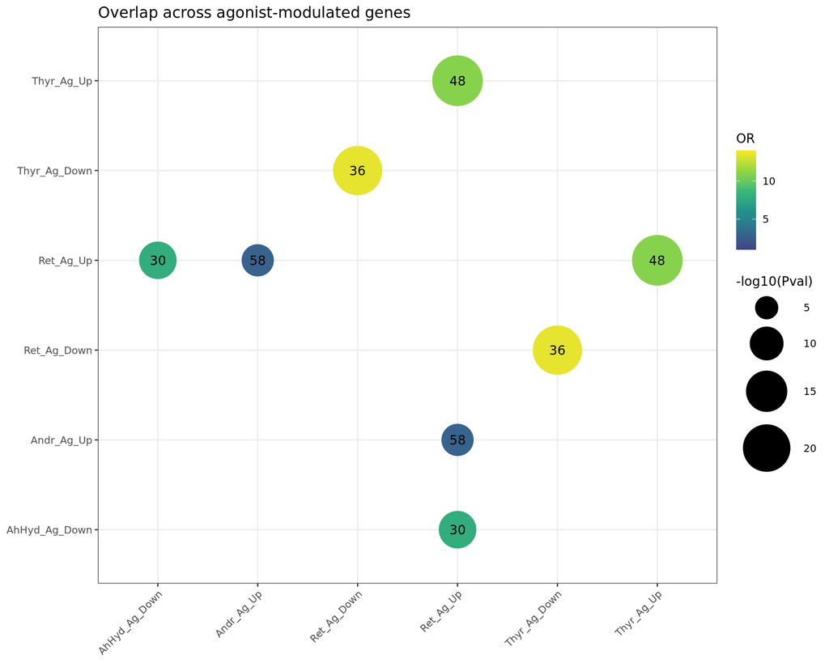

```r
Dot <- ggplot(ResSel, aes(DEGs, KBase, label=Numbers)) +
  geom_point(aes(size=-log10(Pval), col=OR)) +
  geom_text() +
  scale_size_continuous(range=c(2, 20), limits=c(2, round(-log10(min(ResSel$Pval)) + 0.5))) +
  scale_color_viridis_c(limits=c(1, round(max(ResSel$OR)+1)), begin=0.2) + xlab('') + ylab('') +
  theme_bw() +
  theme(axis.line = element_blank(), axis.title = element_blank(),
        axis.text.x = element_text(angle = 45, hjust = 1)) +
  ggtitle('Overlap across agonist-modulated genes')

Dot
```

```r
ggsave(Dot, filename=paste0(OutputFolder, 'DotPlot_Agonist.pdf'), width=8, height=8)
```

## 3.3 Visualize overlap results selectively for retinoic, liverX, estrogen, thyroid

### Selection

```r
Path <- c('Thyr_Ag_Up', 'Thyr_Ag_Down', 'Ret_Ag_Up', 'Ret_Ag_Down',
          'Estr_Ag_Up', 'Estr_Ag_Down', 'LivX_Ag_Up', 'LivX_Ag_Down')
ResPath <- ResSel[ResSel$DEGs %in% Path & ResSel$KBase %in% Path, ]

ResPath
```

```
##           DEGs        KBase       OR         Pval Numbers
## 1    Ret_Ag_Up   Thyr_Ag_Up 10.95105 1.137907e-23      48
## 2  Ret_Ag_Down Thyr_Ag_Down 13.39033 2.579072e-22      36
## 3   Thyr_Ag_Up    Ret_Ag_Up 10.95105 1.137907e-23      48
## 6 Thyr_Ag_Down  Ret_Ag_Down 13.39033 2.579072e-22      36
```

### DotPlot: visualization

```r
ResPath <- dplyr::filter(ResPath, OR > 2) %>% dplyr::filter(Numbers > 25)
min(ResPath$Pval)
```

```
## [1] 1.137907e-23
```

```r
max(ResPath$OR)
```

```
## [1] 13.39033
```

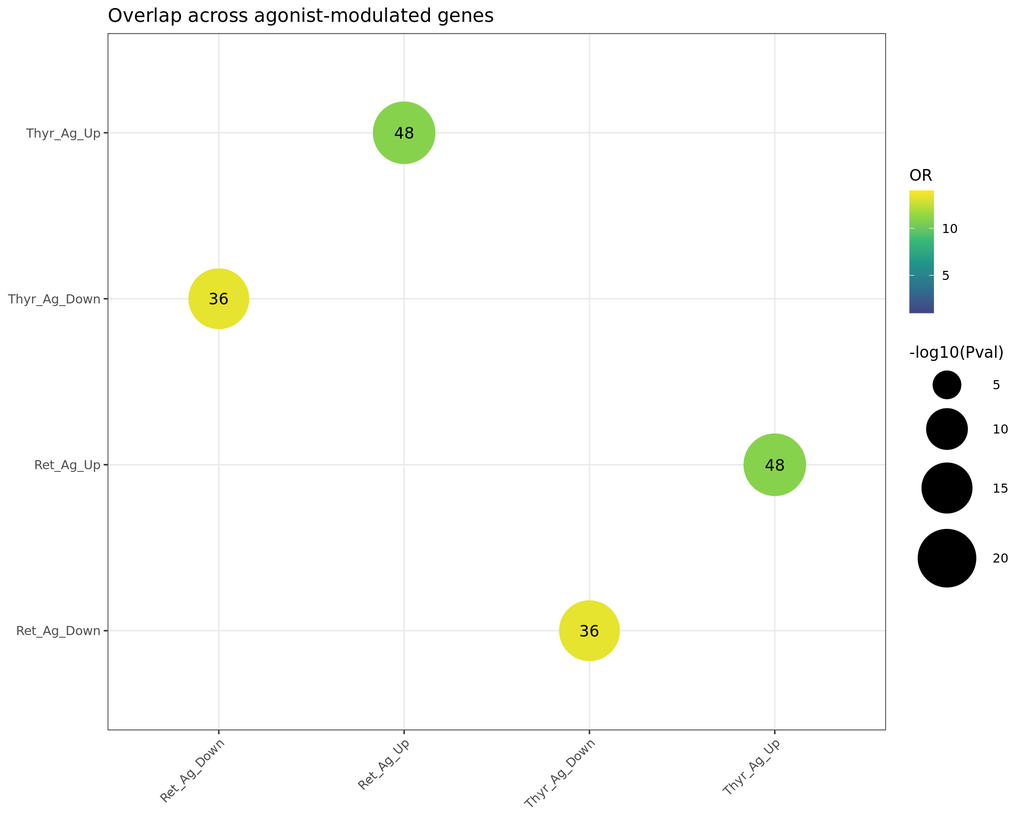

```r
Dot <- ggplot(ResPath, aes(DEGs, KBase, label=Numbers)) +
  geom_point(aes(size=-log10(Pval), col=OR)) +
  geom_text() +
  scale_size_continuous(range=c(2, 20), limits=c(2, round(-log10(min(ResSel$Pval)) + 0.5))) +
  scale_color_viridis_c(limits=c(1, round(max(ResSel$OR)+1)), begin=0.2) + xlab('') + ylab('') +
  theme_bw() +
  theme(axis.line = element_blank(), axis.title = element_blank(),
        axis.text.x = element_text(angle = 45, hjust = 1))+
  ggtitle('Overlap across agonist-modulated genes')


Dot
```

```r
ggsave(Dot, filename=paste0(OutputFolder, 'DotPlot_Agonist_Selected.pdf'), width=8, height=8)
```

# 4. Comparison across pathways: treatment with Inhibitor

## 4.1 Perform Overlap

```r
DEGs_Inh <- list(

  Thyr_Inh_Up= row.names(DEA$Thyr$Inhibitor$DEGs[DEA$Thyr$Inhibitor$DEGs$log2FoldChange > 0, ]),
  Thyr_Inh_Down= row.names(DEA$Thyr$Inhibitor$DEGs[DEA$Thyr$Inhibitor$DEGs$log2FoldChange < 0, ]),

  Ret_Inh_Up= row.names(DEA$Ret$Inhibitor$DEGs[DEA$Ret$Inhibitor$DEGs$log2FoldChange > 0, ]),
  Ret_Inh_Down= row.names(DEA$Ret$Inhibitor$DEGs[DEA$Ret$Inhibitor$DEGs$log2FoldChange < 0, ]),

  Estr_Inh_Up= row.names(DEA$Estr$Inhibitor$DEGs[DEA$Estr$Inhibitor$DEGs$log2FoldChange > 0, ]),
  Estr_Inh_Down= row.names(DEA$Estr$Inhibitor$DEGs[DEA$Estr$Inhibitor$DEGs$log2FoldChange < 0, ]),

  Andr_Inh_Up= row.names(DEA$Andr$Inhibitor$DEGs[DEA$Andr$Inhibitor$DEGs$log2FoldChange > 0, ]),
  Andr_Inh_Down= row.names(DEA$Andr$Inhibitor$DEGs[DEA$Andr$Inhibitor$DEGs$log2FoldChange < 0, ]),

  GC_Inh_Up= row.names(DEA$GC$Inhibitor$DEGs[DEA$GC$Inhibitor$DEGs$log2FoldChange > 0, ]),
  GC_Inh_Down= row.names(DEA$GC$Inhibitor$DEGs[DEA$GC$Inhibitor$DEGs$log2FoldChange < 0, ]),

  LivX_Inh_Up= row.names(DEA$LivX$Inhibitor$DEGs[DEA$LivX$Inhibitor$DEGs$log2FoldChange > 0, ]),
  LivX_Inh_Down= row.names(DEA$LivX$Inhibitor$DEGs[DEA$LivX$Inhibitor$DEGs$log2FoldChange < 0, ]),

  AhHyd_Inh_Up= row.names(DEA$AhHyd$Inhibitor$DEGs[DEA$AhHyd$Inhibitor$DEGs$log2FoldChange > 0, ]),
  AhHyd_Inh_Down= row.names(DEA$AhHyd$Inhibitor$DEGs[DEA$AhHyd$Inhibitor$DEGs$log2FoldChange < 0, ])

            )
```

```r
Universe <- row.names(DEA$Ret$Inhibitor$Res) %>% unique()
length(Universe)
```

```
## [1] 14305
```

```r
OvObj <- newGOM(DEGs_Inh, DEGs_Inh, genome.size=length(Universe))
print(OvObj)
## A GeneOverlapMatrix object:
## ###### Intersection ######
##                Thyr_Inh_Up Thyr_Inh_Down Ret_Inh_Up Ret_Inh_Down Estr_Inh_Up
## Thyr_Inh_Up            160             0          8           19          17
## Thyr_Inh_Down            0           257         14           12           0
## Ret_Inh_Up               8            14        147            0           5
## Ret_Inh_Down            19            12          0          640           4
## Estr_Inh_Up             17             0          5            4          26
## Estr_Inh_Down            0            36          0           10           0
## Andr_Inh_Up              2             0          2            0           2
## Andr_Inh_Down            1            12          0            4           0
## GC_Inh_Up              103             0          5           23          17
## GC_Inh_Down              0           177         24           10           1
## LivX_Inh_Up            107             0          6           24          18
## LivX_Inh_Down            0           135         23            7           2
## AhHyd_Inh_Up            22             6         11           48           4
## AhHyd_Inh_Down           8            57          2           16           0
##                Estr_Inh_Down Andr_Inh_Up Andr_Inh_Down GC_Inh_Up GC_Inh_Down
## Thyr_Inh_Up                0           2             1       103           0
## Thyr_Inh_Down             36           0            12         0         177
## Ret_Inh_Up                 0           2             0         5          24
## Ret_Inh_Down              10           0             4        23          10
## Estr_Inh_Up                0           2             0        17           1
## Estr_Inh_Down             56           0             8         0          39
## Andr_Inh_Up                0          11             0         3           0
## Andr_Inh_Down              8           0            20         0          11
## GC_Inh_Up                  0           3             0       143           0
## GC_Inh_Down               39           0            11         0         294
## LivX_Inh_Up                0           3             0        93           0
## LivX_Inh_Down             26           0             9         0         155
## AhHyd_Inh_Up               3           8             0        27           8
## AhHyd_Inh_Down            17           0            15         5          57
##                LivX_Inh_Up LivX_Inh_Down AhHyd_Inh_Up AhHyd_Inh_Down
## Thyr_Inh_Up            107             0           22              8
## Thyr_Inh_Down            0           135            6             57
## Ret_Inh_Up               6            23           11              2
## Ret_Inh_Down            24             7           48             16
## Estr_Inh_Up             18             2            4              0
## Estr_Inh_Down            0            26            3             17
## Andr_Inh_Up              3             0            8              0
## Andr_Inh_Down            0             9            0             15
## GC_Inh_Up               93             0           27              5
## GC_Inh_Down              0           155            8             57
## LivX_Inh_Up            149             0           18              7
## LivX_Inh_Down            0           202            9             39
## AhHyd_Inh_Up            18             9          229              0
## AhHyd_Inh_Down           7            39            0            134
## ###### P-value ######
##                  Thyr_Inh_Up Thyr_Inh_Down   Ret_Inh_Up Ret_Inh_Down
## Thyr_Inh_Up     0.000000e+00  1.000000e+00 2.460360e-04 9.792842e-05
## Thyr_Inh_Down   1.000000e+00  0.000000e+00 4.071963e-07 4.818121e-01
## Ret_Inh_Up      2.460360e-04  4.071963e-07 0.000000e+00 1.000000e+00
## Ret_Inh_Down    9.792842e-05  4.818121e-01 1.000000e+00 0.000000e+00
## Estr_Inh_Up     8.053782e-28  1.000000e+00 5.916284e-06 2.711290e-02
## Estr_Inh_Down   1.000000e+00  6.684890e-50 1.000000e+00 1.652791e-04
## Andr_Inh_Up     6.399483e-03  1.000000e+00 5.428334e-03 1.000000e+00
## Andr_Inh_Down   2.015707e-01  9.704536e-17 1.000000e+00 1.084916e-02
## GC_Inh_Up      6.600656e-185  1.000000e+00 1.604266e-02 8.851576e-08
## GC_Inh_Down     1.000000e+00 4.525907e-261 3.003206e-15 8.527122e-01
## LivX_Inh_Up    7.156443e-193  1.000000e+00 4.384561e-03 4.516015e-08
## LivX_Inh_Down   1.000000e+00 7.883616e-201 7.649489e-18 8.047628e-01
## AhHyd_Inh_Up    9.863282e-15  2.304721e-01 2.439886e-05 1.193595e-19
## AhHyd_Inh_Down  1.300390e-04  4.969385e-65 4.014797e-01 3.196646e-04
##                 Estr_Inh_Up Estr_Inh_Down  Andr_Inh_Up Andr_Inh_Down
## Thyr_Inh_Up    8.053782e-28  1.000000e+00 6.399483e-03  2.015707e-01
## Thyr_Inh_Down  1.000000e+00  6.684890e-50 1.000000e+00  9.704536e-17
## Ret_Inh_Up     5.916284e-06  1.000000e+00 5.428334e-03  1.000000e+00
## Ret_Inh_Down   2.711290e-02  1.652791e-04 1.000000e+00  1.084916e-02
## Estr_Inh_Up    3.739447e-82  1.000000e+00 1.729647e-04  1.000000e+00
## Estr_Inh_Down  1.000000e+00 1.553685e-158 1.000000e+00  3.977371e-15
## Andr_Inh_Up    1.729647e-04  1.000000e+00 7.806555e-39  1.000000e+00
## Andr_Inh_Down  1.000000e+00  3.977371e-15 1.000000e+00  1.914866e-65
## GC_Inh_Up      1.080777e-28  1.000000e+00 1.521924e-04  1.000000e+00
## GC_Inh_Down    4.174868e-01  8.701825e-54 1.000000e+00  3.269870e-14
## LivX_Inh_Up    1.052311e-30  1.000000e+00 1.718767e-04  1.000000e+00
## LivX_Inh_Down  5.165985e-02  6.967515e-34 1.000000e+00  2.742714e-12
## AhHyd_Inh_Up   7.250604e-04  6.045316e-02 6.045054e-13  1.000000e+00
## AhHyd_Inh_Down 1.000000e+00  8.339853e-22 1.000000e+00  2.497908e-27
##                    GC_Inh_Up   GC_Inh_Down   LivX_Inh_Up LivX_Inh_Down
## Thyr_Inh_Up    6.600656e-185  1.000000e+00 7.156443e-193  1.000000e+00
## Thyr_Inh_Down   1.000000e+00 4.525907e-261  1.000000e+00 7.883616e-201
## Ret_Inh_Up      1.604266e-02  3.003206e-15  4.384561e-03  7.649489e-18
## Ret_Inh_Down    8.851576e-08  8.527122e-01  4.516015e-08  8.047628e-01
## Estr_Inh_Up     1.080777e-28  4.174868e-01  1.052311e-30  5.165985e-02
## Estr_Inh_Down   1.000000e+00  8.701825e-54  1.000000e+00  6.967515e-34
## Andr_Inh_Up     1.521924e-04  1.000000e+00  1.718767e-04  1.000000e+00
## Andr_Inh_Down   1.000000e+00  3.269870e-14  1.000000e+00  2.742714e-12
## GC_Inh_Up       0.000000e+00  1.000000e+00 2.256262e-162  1.000000e+00
## GC_Inh_Down     1.000000e+00  0.000000e+00  1.000000e+00 1.370752e-237
## LivX_Inh_Up    2.256262e-162  1.000000e+00  0.000000e+00  1.000000e+00
## LivX_Inh_Down   1.000000e+00 1.370752e-237  1.000000e+00  0.000000e+00
## AhHyd_Inh_Up    1.443761e-21  1.006674e-01  2.683146e-11  5.291673e-03
## AhHyd_Inh_Down  1.110745e-02  2.156529e-61  5.032755e-04  4.722935e-41
##                AhHyd_Inh_Up AhHyd_Inh_Down
## Thyr_Inh_Up    9.863282e-15   1.300390e-04
## Thyr_Inh_Down  2.304721e-01   4.969385e-65
## Ret_Inh_Up     2.439886e-05   4.014797e-01
## Ret_Inh_Down   1.193595e-19   3.196646e-04
## Estr_Inh_Up    7.250604e-04   1.000000e+00
## Estr_Inh_Down  6.045316e-02   8.339853e-22
## Andr_Inh_Up    6.045054e-13   1.000000e+00
## Andr_Inh_Down  1.000000e+00   2.497908e-27
## GC_Inh_Up      1.443761e-21   1.110745e-02
## GC_Inh_Down    1.006674e-01   2.156529e-61
## LivX_Inh_Up    2.683146e-11   5.032755e-04
## LivX_Inh_Down  5.291673e-03   4.722935e-41
## AhHyd_Inh_Up   0.000000e+00   1.000000e+00
## AhHyd_Inh_Down 1.000000e+00   0.000000e+00
## ###### Odds Ratio ######
##                Thyr_Inh_Up Thyr_Inh_Down Ret_Inh_Up Ret_Inh_Down Estr_Inh_Up
## Thyr_Inh_Up            Inf      0.000000   5.301812    2.9342197  185.216597
## Thyr_Inh_Down     0.000000           Inf   6.025815    1.0466803    0.000000
## Ret_Inh_Up        5.301812      6.025815        Inf    0.0000000   23.657303
## Ret_Inh_Down      2.934220      1.046680   0.000000          Inf    3.899834
## Estr_Inh_Up     185.216597      0.000000  23.657303    3.8998341         Inf
## Estr_Inh_Down     0.000000    113.747546   0.000000    4.6981515    0.000000
## Andr_Inh_Up      19.852088      0.000000  21.671062    0.0000000  131.212371
## Andr_Inh_Down     4.674573     85.721173   0.000000    5.3638099    0.000000
## GC_Inh_Up       643.982238      0.000000   3.577026    4.2068851  210.165381
## GC_Inh_Down       0.000000    261.728337  10.030152    0.7478817    1.909251
## LivX_Inh_Up     680.541601      0.000000   4.169265    4.2194779  241.447440
## LivX_Inh_Down     0.000000    229.219257  14.477847    0.7638911    5.864338
## AhHyd_Inh_Up     10.725756      1.481887   5.170198    6.0384071   11.349242
## AhHyd_Inh_Down    5.854020     51.576644   1.465541    2.9433413    0.000000
##                Estr_Inh_Down Andr_Inh_Up Andr_Inh_Down  GC_Inh_Up GC_Inh_Down
## Thyr_Inh_Up         0.000000    19.85209      4.674573 643.982238   0.0000000
## Thyr_Inh_Down     113.747546     0.00000     85.721173   0.000000 261.7283374
## Ret_Inh_Up          0.000000    21.67106      0.000000   3.577026  10.0301520
## Ret_Inh_Down        4.698151     0.00000      5.363810   4.206885   0.7478817
## Estr_Inh_Up         0.000000   131.21237      0.000000 210.165381   1.9092510
## Estr_Inh_Down            Inf     0.00000    195.929068   0.000000 125.6235132
## Andr_Inh_Up         0.000000         Inf      0.000000  37.842924   0.0000000
## Andr_Inh_Down     195.929068     0.00000           Inf   0.000000  60.4186984
## GC_Inh_Up           0.000000    37.84292      0.000000        Inf   0.0000000
## GC_Inh_Down       125.623513     0.00000     60.418698   0.000000         Inf
## LivX_Inh_Up         0.000000    36.27646      0.000000 462.155024   0.0000000
## LivX_Inh_Down      69.118348     0.00000     59.590522   0.000000 328.9124164
## AhHyd_Inh_Up        3.511547   169.02939      0.000000  16.074371   1.7453123
## AhHyd_Inh_Down     52.500274     0.00000    353.654463   3.940650  43.4566049
##                LivX_Inh_Up LivX_Inh_Down AhHyd_Inh_Up AhHyd_Inh_Down
## Thyr_Inh_Up     680.541601     0.0000000    10.725756       5.854020
## Thyr_Inh_Down     0.000000   229.2192571     1.481887      51.576644
## Ret_Inh_Up        4.169265    14.4778467     5.170198       1.465541
## Ret_Inh_Down      4.219478     0.7638911     6.038407       2.943341
## Estr_Inh_Up     241.447440     5.8643380    11.349242       0.000000
## Estr_Inh_Down     0.000000    69.1183483     3.511547      52.500274
## Andr_Inh_Up      36.276463     0.0000000   169.029389       0.000000
## Andr_Inh_Down     0.000000    59.5905220     0.000000     353.654463
## GC_Inh_Up       462.155024     0.0000000    16.074371       3.940650
## GC_Inh_Down       0.000000   328.9124164     1.745312      43.456605
## LivX_Inh_Up            Inf     0.0000000     9.075724       5.444470
## LivX_Inh_Down     0.000000           Inf     2.942282      35.230183
## AhHyd_Inh_Up      9.075724     2.9422822          Inf       0.000000
## AhHyd_Inh_Down    5.444470    35.2301826     0.000000            Inf
## ###### Jaccard Index ######
##                Thyr_Inh_Up Thyr_Inh_Down  Ret_Inh_Up Ret_Inh_Down Estr_Inh_Up
## Thyr_Inh_Up    1.000000000    0.00000000 0.026755853  0.024327785 0.100591716
## Thyr_Inh_Down  0.000000000    1.00000000 0.035897436  0.013559322 0.000000000
## Ret_Inh_Up     0.026755853    0.03589744 1.000000000  0.000000000 0.029761905
## Ret_Inh_Down   0.024327785    0.01355932 0.000000000  1.000000000 0.006042296
## Estr_Inh_Up    0.100591716    0.00000000 0.029761905  0.006042296 1.000000000
## Estr_Inh_Down  0.000000000    0.12996390 0.000000000  0.014577259 0.000000000
## Andr_Inh_Up    0.011834320    0.00000000 0.012820513  0.000000000 0.057142857
## Andr_Inh_Down  0.005586592    0.04528302 0.000000000  0.006097561 0.000000000
## GC_Inh_Up      0.515000000    0.00000000 0.017543860  0.030263158 0.111842105
## GC_Inh_Down    0.000000000    0.47326203 0.057553957  0.010822511 0.003134796
```

```r
## LivX_Inh_Up    0.529702970    0.00000000 0.020689655  0.031372549 0.114649682
## LivX_Inh_Down  0.000000000    0.41666667 0.070552147  0.008383234 0.008849558
## AhHyd_Inh_Up   0.059945504    0.01250000 0.030136986  0.058465286 0.015936255
## AhHyd_Inh_Down 0.027972028    0.17065868 0.007168459  0.021108179 0.000000000
##                Estr_Inh_Down Andr_Inh_Up Andr_Inh_Down  GC_Inh_Up GC_Inh_Down
## Thyr_Inh_Up       0.00000000  0.01183432   0.005586592 0.51500000 0.000000000
## Thyr_Inh_Down     0.12996390  0.00000000   0.045283019 0.00000000 0.473262032
## Ret_Inh_Up        0.00000000  0.01282051   0.000000000 0.01754386 0.057553957
## Ret_Inh_Down      0.01457726  0.00000000   0.006097561 0.03026316 0.010822511
## Estr_Inh_Up       0.00000000  0.05714286   0.000000000 0.11184211 0.003134796
## Estr_Inh_Down     1.00000000  0.00000000   0.117647059 0.00000000 0.125401929
## Andr_Inh_Up       0.00000000  1.00000000   0.000000000 0.01986755 0.000000000
## Andr_Inh_Down     0.11764706  0.00000000   1.000000000 0.00000000 0.036303630
## GC_Inh_Up         0.00000000  0.01986755   0.000000000 1.00000000 0.000000000
## GC_Inh_Down       0.12540193  0.00000000   0.036303630 0.00000000 1.000000000
## LivX_Inh_Up       0.00000000  0.01910828   0.000000000 0.46733668 0.000000000
## LivX_Inh_Down     0.11206897  0.00000000   0.042253521 0.00000000 0.454545455
## AhHyd_Inh_Up      0.01063830  0.03448276   0.000000000 0.07826087 0.015533981
## AhHyd_Inh_Down    0.09826590  0.00000000   0.107913669 0.01838235 0.153638814
##                LivX_Inh_Up LivX_Inh_Down AhHyd_Inh_Up AhHyd_Inh_Down
## Thyr_Inh_Up     0.52970297   0.000000000   0.05994550    0.027972028
## Thyr_Inh_Down   0.00000000   0.416666667   0.01250000    0.170658683
## Ret_Inh_Up      0.02068966   0.070552147   0.03013699    0.007168459
## Ret_Inh_Down    0.03137255   0.008383234   0.05846529    0.021108179
## Estr_Inh_Up     0.11464968   0.008849558   0.01593625    0.000000000
## Estr_Inh_Down   0.00000000   0.112068966   0.01063830    0.098265896
## Andr_Inh_Up     0.01910828   0.000000000   0.03448276    0.000000000
## Andr_Inh_Down   0.00000000   0.042253521   0.00000000    0.107913669
## GC_Inh_Up       0.46733668   0.000000000   0.07826087    0.018382353
## GC_Inh_Down     0.00000000   0.454545455   0.01553398    0.153638814
## LivX_Inh_Up     1.00000000   0.000000000   0.05000000    0.025362319
## LivX_Inh_Down   0.00000000   1.000000000   0.02132701    0.131313131
## AhHyd_Inh_Up    0.05000000   0.021327014   1.00000000    0.000000000
## AhHyd_Inh_Down  0.02536232   0.131313131   0.00000000    1.000000000
```

```r
getMatrix(OvObj, name='intersection')
```

```
##                Thyr_Inh_Up Thyr_Inh_Down Ret_Inh_Up Ret_Inh_Down Estr_Inh_Up
## Thyr_Inh_Up            160             0          8           19          17
## Thyr_Inh_Down            0           257         14           12           0
## Ret_Inh_Up               8            14        147            0           5
## Ret_Inh_Down            19            12          0          640           4
## Estr_Inh_Up             17             0          5            4          26
## Estr_Inh_Down            0            36          0           10           0
## Andr_Inh_Up              2             0          2            0           2
## Andr_Inh_Down            1            12          0            4           0
## GC_Inh_Up              103             0          5           23          17
## GC_Inh_Down              0           177         24           10           1
## LivX_Inh_Up            107             0          6           24          18
## LivX_Inh_Down            0           135         23            7           2
## AhHyd_Inh_Up            22             6         11           48           4
## AhHyd_Inh_Down           8            57          2           16           0
##                Estr_Inh_Down Andr_Inh_Up Andr_Inh_Down GC_Inh_Up GC_Inh_Down
## Thyr_Inh_Up                0           2             1       103           0
## Thyr_Inh_Down             36           0            12         0         177
## Ret_Inh_Up                 0           2             0         5          24
## Ret_Inh_Down              10           0             4        23          10
## Estr_Inh_Up                0           2             0        17           1
## Estr_Inh_Down             56           0             8         0          39
## Andr_Inh_Up                0          11             0         3           0
## Andr_Inh_Down              8           0            20         0          11
## GC_Inh_Up                  0           3             0       143           0
## GC_Inh_Down               39           0            11         0         294
## LivX_Inh_Up                0           3             0        93           0
## LivX_Inh_Down             26           0             9         0         155
## AhHyd_Inh_Up               3           8             0        27           8
## AhHyd_Inh_Down            17           0            15         5          57
##                LivX_Inh_Up LivX_Inh_Down AhHyd_Inh_Up AhHyd_Inh_Down
## Thyr_Inh_Up            107             0           22              8
## Thyr_Inh_Down            0           135            6             57
## Ret_Inh_Up               6            23           11              2
## Ret_Inh_Down            24             7           48             16
## Estr_Inh_Up             18             2            4              0
## Estr_Inh_Down            0            26            3             17
## Andr_Inh_Up              3             0            8              0
## Andr_Inh_Down            0             9            0             15
## GC_Inh_Up               93             0           27              5
## GC_Inh_Down              0           155            8             57
## LivX_Inh_Up            149             0           18              7
## LivX_Inh_Down            0           202            9             39
## AhHyd_Inh_Up            18             9          229              0
## AhHyd_Inh_Down           7            39            0            134
```

```r
getMatrix(OvObj, name='pval')
```

```
##                  Thyr_Inh_Up Thyr_Inh_Down   Ret_Inh_Up Ret_Inh_Down
## Thyr_Inh_Up     0.000000e+00  1.000000e+00 2.460360e-04 9.792842e-05
## Thyr_Inh_Down   1.000000e+00  0.000000e+00 4.071963e-07 4.818121e-01
## Ret_Inh_Up      2.460360e-04  4.071963e-07 0.000000e+00 1.000000e+00
## Ret_Inh_Down    9.792842e-05  4.818121e-01 1.000000e+00 0.000000e+00
## Estr_Inh_Up     8.053782e-28  1.000000e+00 5.916284e-06 2.711290e-02
## Estr_Inh_Down   1.000000e+00  6.684890e-50 1.000000e+00 1.652791e-04
## Andr_Inh_Up     6.399483e-03  1.000000e+00 5.428334e-03 1.000000e+00
## Andr_Inh_Down   2.015707e-01  9.704536e-17 1.000000e+00 1.084916e-02
## GC_Inh_Up      6.600656e-185  1.000000e+00 1.604266e-02 8.851576e-08
## GC_Inh_Down     1.000000e+00 4.525907e-261 3.003206e-15 8.527122e-01
## LivX_Inh_Up    7.156443e-193  1.000000e+00 4.384561e-03 4.516015e-08
## LivX_Inh_Down   1.000000e+00 7.883616e-201 7.649489e-18 8.047628e-01
## AhHyd_Inh_Up    9.863282e-15  2.304721e-01 2.439886e-05 1.193595e-19
## AhHyd_Inh_Down  1.300390e-04  4.969385e-65 4.014797e-01 3.196646e-04
##                 Estr_Inh_Up Estr_Inh_Down  Andr_Inh_Up Andr_Inh_Down
## Thyr_Inh_Up    8.053782e-28  1.000000e+00 6.399483e-03  2.015707e-01
## Thyr_Inh_Down  1.000000e+00  6.684890e-50 1.000000e+00  9.704536e-17
## Ret_Inh_Up     5.916284e-06  1.000000e+00 5.428334e-03  1.000000e+00
## Ret_Inh_Down   2.711290e-02  1.652791e-04 1.000000e+00  1.084916e-02
## Estr_Inh_Up    3.739447e-82  1.000000e+00 1.729647e-04  1.000000e+00
## Estr_Inh_Down  1.000000e+00 1.553685e-158 1.000000e+00  3.977371e-15
## Andr_Inh_Up    1.729647e-04  1.000000e+00 7.806555e-39  1.000000e+00
## Andr_Inh_Down  1.000000e+00  3.977371e-15 1.000000e+00  1.914866e-65
## GC_Inh_Up      1.080777e-28  1.000000e+00 1.521924e-04  1.000000e+00
## GC_Inh_Down    4.174868e-01  8.701825e-54 1.000000e+00  3.269870e-14
## LivX_Inh_Up    1.052311e-30  1.000000e+00 1.718767e-04  1.000000e+00
## LivX_Inh_Down  5.165985e-02  6.967515e-34 1.000000e+00  2.742714e-12
## AhHyd_Inh_Up   7.250604e-04  6.045316e-02 6.045054e-13  1.000000e+00
## AhHyd_Inh_Down 1.000000e+00  8.339853e-22 1.000000e+00  2.497908e-27
##                    GC_Inh_Up   GC_Inh_Down   LivX_Inh_Up LivX_Inh_Down
## Thyr_Inh_Up    6.600656e-185  1.000000e+00 7.156443e-193  1.000000e+00
## Thyr_Inh_Down   1.000000e+00 4.525907e-261  1.000000e+00 7.883616e-201
## Ret_Inh_Up      1.604266e-02  3.003206e-15  4.384561e-03  7.649489e-18
## Ret_Inh_Down    8.851576e-08  8.527122e-01  4.516015e-08  8.047628e-01
## Estr_Inh_Up     1.080777e-28  4.174868e-01  1.052311e-30  5.165985e-02
## Estr_Inh_Down   1.000000e+00  8.701825e-54  1.000000e+00  6.967515e-34
## Andr_Inh_Up     1.521924e-04  1.000000e+00  1.718767e-04  1.000000e+00
## Andr_Inh_Down   1.000000e+00  3.269870e-14  1.000000e+00  2.742714e-12
## GC_Inh_Up       0.000000e+00  1.000000e+00 2.256262e-162  1.000000e+00
## GC_Inh_Down     1.000000e+00  0.000000e+00  1.000000e+00 1.370752e-237
## LivX_Inh_Up    2.256262e-162  1.000000e+00  0.000000e+00  1.000000e+00
## LivX_Inh_Down   1.000000e+00 1.370752e-237  1.000000e+00  0.000000e+00
## AhHyd_Inh_Up    1.443761e-21  1.006674e-01  2.683146e-11  5.291673e-03
## AhHyd_Inh_Down  1.110745e-02  2.156529e-61  5.032755e-04  4.722935e-41
##                AhHyd_Inh_Up AhHyd_Inh_Down
## Thyr_Inh_Up    9.863282e-15   1.300390e-04
## Thyr_Inh_Down  2.304721e-01   4.969385e-65
## Ret_Inh_Up     2.439886e-05   4.014797e-01
## Ret_Inh_Down   1.193595e-19   3.196646e-04
## Estr_Inh_Up    7.250604e-04   1.000000e+00
## Estr_Inh_Down  6.045316e-02   8.339853e-22
## Andr_Inh_Up    6.045054e-13   1.000000e+00
## Andr_Inh_Down  1.000000e+00   2.497908e-27
## GC_Inh_Up      1.443761e-21   1.110745e-02
## GC_Inh_Down    1.006674e-01   2.156529e-61
## LivX_Inh_Up    2.683146e-11   5.032755e-04
## LivX_Inh_Down  5.291673e-03   4.722935e-41
## AhHyd_Inh_Up   0.000000e+00   1.000000e+00
## AhHyd_Inh_Down 1.000000e+00   0.000000e+00
```

```r
getMatrix(OvObj, name='odds.ratio')
```

```
##                Thyr_Inh_Up Thyr_Inh_Down Ret_Inh_Up Ret_Inh_Down Estr_Inh_Up
## Thyr_Inh_Up            Inf      0.000000   5.301812    2.9342197  185.216597
## Thyr_Inh_Down     0.000000           Inf   6.025815    1.0466803    0.000000
## Ret_Inh_Up        5.301812      6.025815        Inf    0.0000000   23.657303
## Ret_Inh_Down      2.934220      1.046680   0.000000          Inf    3.899834
## Estr_Inh_Up     185.216597      0.000000  23.657303    3.8998341         Inf
## Estr_Inh_Down     0.000000    113.747546   0.000000    4.6981515    0.000000
## Andr_Inh_Up      19.852088      0.000000  21.671062    0.0000000  131.212371
## Andr_Inh_Down     4.674573     85.721173   0.000000    5.3638099    0.000000
## GC_Inh_Up       643.982238      0.000000   3.577026    4.2068851  210.165381
## GC_Inh_Down       0.000000    261.728337  10.030152    0.7478817    1.909251
## LivX_Inh_Up     680.541601      0.000000   4.169265    4.2194779  241.447440
## LivX_Inh_Down     0.000000    229.219257  14.477847    0.7638911    5.864338
## AhHyd_Inh_Up     10.725756      1.481887   5.170198    6.0384071   11.349242
## AhHyd_Inh_Down    5.854020     51.576644   1.465541    2.9433413    0.000000
##                Estr_Inh_Down Andr_Inh_Up Andr_Inh_Down  GC_Inh_Up GC_Inh_Down
## Thyr_Inh_Up         0.000000    19.85209      4.674573 643.982238   0.0000000
## Thyr_Inh_Down     113.747546     0.00000     85.721173   0.000000 261.7283374
## Ret_Inh_Up          0.000000    21.67106      0.000000   3.577026  10.0301520
## Ret_Inh_Down        4.698151     0.00000      5.363810   4.206885   0.7478817
## Estr_Inh_Up         0.000000   131.21237      0.000000 210.165381   1.9092510
## Estr_Inh_Down            Inf     0.00000    195.929068   0.000000 125.6235132
## Andr_Inh_Up         0.000000         Inf      0.000000  37.842924   0.0000000
## Andr_Inh_Down     195.929068     0.00000           Inf   0.000000  60.4186984
## GC_Inh_Up           0.000000    37.84292      0.000000        Inf   0.0000000
## GC_Inh_Down       125.623513     0.00000     60.418698   0.000000         Inf
## LivX_Inh_Up         0.000000    36.27646      0.000000 462.155024   0.0000000
## LivX_Inh_Down      69.118348     0.00000     59.590522   0.000000 328.9124164
## AhHyd_Inh_Up        3.511547   169.02939      0.000000  16.074371   1.7453123
## AhHyd_Inh_Down     52.500274     0.00000    353.654463   3.940650  43.4566049
##                LivX_Inh_Up LivX_Inh_Down AhHyd_Inh_Up AhHyd_Inh_Down
## Thyr_Inh_Up     680.541601     0.0000000    10.725756       5.854020
## Thyr_Inh_Down     0.000000   229.2192571     1.481887      51.576644
## Ret_Inh_Up        4.169265    14.4778467     5.170198       1.465541
## Ret_Inh_Down      4.219478     0.7638911     6.038407       2.943341
## Estr_Inh_Up     241.447440     5.8643380    11.349242       0.000000
## Estr_Inh_Down     0.000000    69.1183483     3.511547      52.500274
## Andr_Inh_Up      36.276463     0.0000000   169.029389       0.000000
## Andr_Inh_Down     0.000000    59.5905220     0.000000     353.654463
## GC_Inh_Up       462.155024     0.0000000    16.074371       3.940650
## GC_Inh_Down       0.000000   328.9124164     1.745312      43.456605
## LivX_Inh_Up            Inf     0.0000000     9.075724       5.444470
## LivX_Inh_Down     0.000000           Inf     2.942282      35.230183
## AhHyd_Inh_Up      9.075724     2.9422822          Inf       0.000000
## AhHyd_Inh_Down    5.444470    35.2301826     0.000000            Inf
```

## 4.2 Visualize overlap results

### DotPlot: data preparation

```r
OR <- data.frame(getMatrix(OvObj, name='odds.ratio'))
OR$DEGs <- row.names(OR)
OR <- gather(OR, 'KBase', 'OR', -DEGs)
PVAL <- data.frame(getMatrix(OvObj, name='pval'))
PVAL$DEGs <- row.names(PVAL)
PVAL <- gather(PVAL, 'KBase', 'PVal', -DEGs)
NUM <- data.frame(getMatrix(OvObj, name='intersection'))
NUM$DEGs <- row.names(NUM)
NUM <- gather(NUM, 'KBase', 'Numbers', -DEGs)
if(! identical(OR$DEGs, PVAL$DEGs)){
  stop('Inconsistecy')
}
if(! identical(OR$DEGs, NUM$DEGs)){
  stop('Inconsistecy')
}
if(! identical(OR$KBase, NUM$KBase)){
  stop('Inconsistecy')
}
if(! identical(OR$KBase, NUM$KBase)){
  stop('Inconsistecy')
}
Res <- mutate(OR, Pval=PVAL$PVal) %>% mutate(Numbers=NUM$Numbers)
Res
```

```
##               DEGs          KBase          OR          Pval Numbers
## 1      Thyr_Inh_Up    Thyr_Inh_Up         Inf  0.000000e+00     160
## 2    Thyr_Inh_Down    Thyr_Inh_Up   0.0000000  1.000000e+00       0
## 3       Ret_Inh_Up    Thyr_Inh_Up   5.3018121  2.460360e-04       8
## 4     Ret_Inh_Down    Thyr_Inh_Up   2.9342197  9.792842e-05      19
## 5      Estr_Inh_Up    Thyr_Inh_Up 185.2165967  8.053782e-28      17
## 6    Estr_Inh_Down    Thyr_Inh_Up   0.0000000  1.000000e+00       0
## 7      Andr_Inh_Up    Thyr_Inh_Up  19.8520878  6.399483e-03       2
## 8    Andr_Inh_Down    Thyr_Inh_Up   4.6745733  2.015707e-01       1
## 9        GC_Inh_Up    Thyr_Inh_Up 643.9822382 6.600656e-185     103
## 10     GC_Inh_Down    Thyr_Inh_Up   0.0000000  1.000000e+00       0
## 11     LivX_Inh_Up    Thyr_Inh_Up 680.5416006 7.156443e-193     107
## 12   LivX_Inh_Down    Thyr_Inh_Up   0.0000000  1.000000e+00       0
## 13    AhHyd_Inh_Up    Thyr_Inh_Up  10.7257561  9.863282e-15      22
## 14  AhHyd_Inh_Down    Thyr_Inh_Up   5.8540200  1.300390e-04       8
```

[output cut: 182 more lines]

```r
ResMod <- Res

ResMod[ResMod$DEGs == ResMod$KBase, ]$OR <- 1
ResMod[ResMod$DEGs == ResMod$KBase, ]$Pval <- 1

ResMod
```

```
##               DEGs          KBase          OR          Pval Numbers
## 1      Thyr_Inh_Up    Thyr_Inh_Up   1.0000000  1.000000e+00     160
## 2    Thyr_Inh_Down    Thyr_Inh_Up   0.0000000  1.000000e+00       0
## 3       Ret_Inh_Up    Thyr_Inh_Up   5.3018121  2.460360e-04       8
## 4     Ret_Inh_Down    Thyr_Inh_Up   2.9342197  9.792842e-05      19
## 5      Estr_Inh_Up    Thyr_Inh_Up 185.2165967  8.053782e-28      17
## 6    Estr_Inh_Down    Thyr_Inh_Up   0.0000000  1.000000e+00       0
## 7      Andr_Inh_Up    Thyr_Inh_Up  19.8520878  6.399483e-03       2
## 8    Andr_Inh_Down    Thyr_Inh_Up   4.6745733  2.015707e-01       1
## 9        GC_Inh_Up    Thyr_Inh_Up 643.9822382 6.600656e-185     103
## 10     GC_Inh_Down    Thyr_Inh_Up   0.0000000  1.000000e+00       0
## 11     LivX_Inh_Up    Thyr_Inh_Up 680.5416006 7.156443e-193     107
## 12   LivX_Inh_Down    Thyr_Inh_Up   0.0000000  1.000000e+00       0
## 13    AhHyd_Inh_Up    Thyr_Inh_Up  10.7257561  9.863282e-15      22
## 14  AhHyd_Inh_Down    Thyr_Inh_Up   5.8540200  1.300390e-04       8
```

[output cut: 182 more lines]

### DotPlot: visualization

I select as significant overlaps having an OR > 2 and at least 25 overlapping genes. Dots are shown for PVals < 0.01 (set in the plot). Max value in the plot must be set according to minimum PVal to avoid dots not to be shown.

```r
ResSel <- dplyr::filter(ResMod, OR > 2) %>% dplyr::filter(Numbers > 25)
min(ResSel$Pval)
```

```
## [1] 4.525907e-261
```

```r
max(ResSel$OR)
```

```
## [1] 680.5416
```

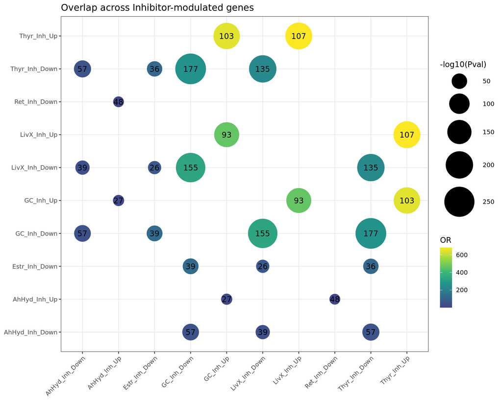

```r
Dot <- ggplot(ResSel, aes(DEGs, KBase, label=Numbers)) +
  geom_point(aes(size=-log10(Pval), col=OR)) +
  geom_text() +
  scale_size_continuous(range=c(2, 20), limits=c(2, round(-log10(min(ResSel$Pval)) + 0.5))) +
  scale_color_viridis_c(limits=c(1, round(max(ResSel$OR)+1)), begin=0.2) + xlab('') + ylab('') +
  theme_bw() +
  theme(axis.line = element_blank(), axis.title = element_blank(),
        axis.text.x = element_text(angle = 45, hjust = 1)) +
    ggtitle('Overlap across Inhibitor-modulated genes')

Dot
```

```r
ggsave(Dot, filename=paste0(OutputFolder, 'DotPlot_Inhibitor.pdf'), width=8, height=8)
```

## 4.3 Visualize overlap results selectively for retinoic, liverX, thyroid

### Selection

```r
Path <- c('Thyr_Inh_Up', 'Thyr_Inh_Down', 'Ret_Inh_Up', 'Ret_Inh_Down', 'LivX_Inh_Up', 'LivX_Inh_Down')
ResPath <- ResSel[ResSel$DEGs %in% Path & ResSel$KBase %in% Path, ]

ResPath
```

```
##             DEGs         KBase       OR          Pval Numbers
## 2    LivX_Inh_Up   Thyr_Inh_Up 680.5416 7.156443e-193     107
## 5  LivX_Inh_Down Thyr_Inh_Down 229.2193 7.883616e-201     135
## 18   Thyr_Inh_Up   LivX_Inh_Up 680.5416 7.156443e-193     107
## 20 Thyr_Inh_Down LivX_Inh_Down 229.2193 7.883616e-201     135
```

### DotPlot: visualization

```r
ResPath <- dplyr::filter(ResPath, OR > 2) %>% dplyr::filter(Numbers > 25)
min(ResPath$Pval)
```

```
## [1] 7.883616e-201
```

```r
max(ResPath$OR)
```

```
## [1] 680.5416
```

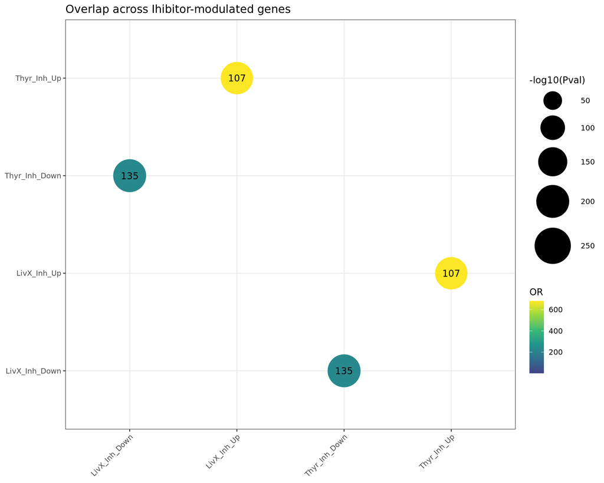

```r
Dot <- ggplot(ResPath, aes(DEGs, KBase, label=Numbers)) +
  geom_point(aes(size=-log10(Pval), col=OR)) +
  geom_text() +
  scale_size_continuous(range=c(2, 20), limits=c(2, round(-log10(min(ResSel$Pval)) + 0.5))) +
  scale_color_viridis_c(limits=c(1, round(max(ResSel$OR)+1)), begin=0.2) + xlab('') + ylab('') +
  theme_bw() +
  theme(axis.line = element_blank(), axis.title = element_blank(),
        axis.text.x = element_text(angle = 45, hjust = 1))+
  ggtitle('Overlap across Ihibitor-modulated genes')


Dot
```

```r
ggsave(Dot, filename=paste0(OutputFolder, 'DotPlot_Inhibitor_Selected.pdf'), width=8, height=8)
```

# 5. Comparison across pathways: up-regulated genes

## 5.1 Perform the overlap

```r
DEGs_UpReg <- list(

  Thyr_Ag= row.names(DEA$Thyr$Agonist$DEGs[DEA$Thyr$Agonist$DEGs$log2FoldChange > 0, ]),
  Thyr_Inh= row.names(DEA$Thyr$Inhibitor$DEGs[DEA$Thyr$Inhibitor$DEGs$log2FoldChange > 0, ]),

  Ret_Ag= row.names(DEA$Ret$Agonist$DEGs[DEA$Ret$Agonist$DEGs$log2FoldChange > 0, ]),
  Ret_Inh= row.names(DEA$Ret$Inhibitor$DEGs[DEA$Ret$Inhibitor$DEGs$log2FoldChange > 0, ]),

  Estr_Ag= row.names(DEA$Estr$Agonist$DEGs[DEA$Estr$Agonist$DEGs$log2FoldChange > 0, ]),
  Estr_Inh= row.names(DEA$Estr$Inhibitor$DEGs[DEA$Estr$Inhibitor$DEGs$log2FoldChange > 0, ]),

  Andr_Ag= row.names(DEA$Andr$Agonist$DEGs[DEA$Andr$Agonist$DEGs$log2FoldChange > 0, ]),
  Andr_Inh= row.names(DEA$Andr$Inhibitor$DEGs[DEA$Andr$Inhibitor$DEGs$log2FoldChange > 0, ]),

  GC_Ag= row.names(DEA$GC$Agonist$DEGs[DEA$GC$Agonist$DEGs$log2FoldChange > 0, ]),
  GC_Inh= row.names(DEA$GC$Inhibitor$DEGs[DEA$GC$Inhibitor$DEGs$log2FoldChange > 0, ]),

  LivX_Ag= row.names(DEA$LivX$Agonist$DEGs[DEA$LivX$Agonist$DEGs$log2FoldChange > 0, ]),
  LivX_Inh= row.names(DEA$LivX$Inhibitor$DEGs[DEA$LivX$Inhibitor$DEGs$log2FoldChange > 0, ]),

  AhHyd_Ag= row.names(DEA$AhHyd$Agonist$DEGs[DEA$AhHyd$Agonist$DEGs$log2FoldChange > 0, ]),
  AhHyd_Inh= row.names(DEA$AhHyd$Inhibitor$DEGs[DEA$AhHyd$Inhibitor$DEGs$log2FoldChange > 0, ])

            )
```

```r
Universe <- row.names(DEA$Ret$Inhibitor$Res) %>% unique()
length(Universe)
```

```
## [1] 14305
```

```r
OvObj <- newGOM(DEGs_UpReg, DEGs_UpReg, genome.size=length(Universe))
print(OvObj)
## A GeneOverlapMatrix object:
## ###### Intersection ######
##           Thyr_Ag Thyr_Inh Ret_Ag Ret_Inh Estr_Ag Estr_Inh Andr_Ag Andr_Inh
## Thyr_Ag        78       12     48       2       1        4       3        1
## Thyr_Inh       12      160     56       8       1       17      88        2
## Ret_Ag         48       56   1861      43       1       11      58        3
## Ret_Inh         2        8     43     147       1        5      12        2
## Estr_Ag         1        1      1       1       1        1       1        1
## Estr_Inh        4       17     11       5       1       26      10        2
## Andr_Ag         3       88     58      12       1       10     197        3
## Andr_Inh        1        2      3       2       1        2       3       11
## GC_Ag           1        1      4       3       1        2       3        1
## GC_Inh         11      103     52       5       1       17      67        3
## LivX_Ag         1        1      2       1       1        3       1        1
## LivX_Inh       15      107     68       6       1       18      77        3
## AhHyd_Ag        2        9      2       2       1        4       3        3
## AhHyd_Inh      13       22     69      11       1        4       2        8
##           GC_Ag GC_Inh LivX_Ag LivX_Inh AhHyd_Ag AhHyd_Inh
## Thyr_Ag       1     11       1       15        2        13
## Thyr_Inh      1    103       1      107        9        22
## Ret_Ag        4     52       2       68        2        69
## Ret_Inh       3      5       1        6        2        11
## Estr_Ag       1      1       1        1        1         1
## Estr_Inh      2     17       3       18        4         4
## Andr_Ag       3     67       1       77        3         2
## Andr_Inh      1      3       1        3        3         8
## GC_Ag         6      1       1        1        1         1
## GC_Inh        1    143       1       93       12        27
## LivX_Ag       1      1      10        1        1         1
## LivX_Inh      1     93       1      149        9        18
## AhHyd_Ag      1     12       1        9       20        11
## AhHyd_Inh     1     27       1       18       11       229
## ###### P-value ######
##                 Thyr_Ag      Thyr_Inh       Ret_Ag      Ret_Inh      Estr_Ag
## Thyr_Ag   1.040621e-209  5.813662e-11 1.137907e-23 1.911799e-01 5.452639e-03
## Thyr_Inh   5.813662e-11  0.000000e+00 7.635477e-13 2.460360e-04 1.118490e-02
## Ret_Ag     1.137907e-23  7.635477e-13 0.000000e+00 1.482210e-07 1.300944e-01
## Ret_Inh    1.911799e-01  2.460360e-04 1.482210e-07 0.000000e+00 1.027613e-02
## Estr_Ag    5.452639e-03  1.118490e-02 1.300944e-01 1.027613e-02 6.990563e-05
## Estr_Inh   1.116213e-05  8.053782e-28 2.073836e-04 5.916284e-06 1.817546e-03
## Andr_Ag    9.265938e-02 4.507804e-128 8.016126e-10 8.798784e-07 1.377141e-02
## Andr_Inh   5.839013e-02  6.399483e-03 1.634049e-01 5.428334e-03 7.689619e-04
## GC_Ag      3.227866e-02  6.527171e-02 3.442533e-03 2.078855e-05 4.194338e-04
## GC_Inh     2.966445e-10 6.600656e-185 9.114956e-13 1.604266e-02 9.996505e-03
## LivX_Ag    5.322409e-02  1.064159e-01 3.807545e-01 9.816670e-02 6.990563e-04
## LivX_Inh   2.241978e-15 7.156443e-193 1.134878e-22 4.384561e-03 1.041594e-02
## AhHyd_Ag   5.232939e-03  3.302718e-13 7.544395e-01 1.765347e-02 1.398113e-03
## AhHyd_Inh  2.836380e-10  9.863282e-15 6.184627e-12 2.439886e-05 1.600839e-02
##               Estr_Inh       Andr_Ag     Andr_Inh        GC_Ag        GC_Inh
## Thyr_Ag   1.116213e-05  9.265938e-02 5.839013e-02 3.227866e-02  2.966445e-10
## Thyr_Inh  8.053782e-28 4.507804e-128 6.399483e-03 6.527171e-02 6.600656e-185
## Ret_Ag    2.073836e-04  8.016126e-10 1.634049e-01 3.442533e-03  9.114956e-13
## Ret_Inh   5.916284e-06  8.798784e-07 5.428334e-03 2.078855e-05  1.604266e-02
## Estr_Ag   1.817546e-03  1.377141e-02 7.689619e-04 4.194338e-04  9.996505e-03
## Estr_Inh  3.739447e-82  8.559337e-13 1.729647e-04 4.743677e-05  1.080777e-28
## Andr_Ag   8.559337e-13  0.000000e+00 3.912194e-04 4.989996e-05  1.944172e-89
## Andr_Inh  1.729647e-04  3.912194e-04 7.806555e-39 4.605714e-03  1.521924e-04
## GC_Ag     4.743677e-05  4.989996e-05 4.605714e-03 8.411255e-23  5.850988e-02
## GC_Inh    1.080777e-28  1.944172e-89 1.521924e-04 5.850988e-02  0.000000e+00
## LivX_Ag   6.342562e-07  1.295240e-01 7.665468e-03 4.187745e-03  9.561473e-02
## LivX_Inh  1.052311e-30 4.583436e-108 1.718767e-04 6.090105e-02 2.256262e-162
## AhHyd_Ag  4.072111e-08  2.467071e-03 3.828855e-07 8.360865e-03  7.326313e-20
## AhHyd_Inh 7.250604e-04  8.269819e-01 6.045054e-13 9.230286e-02  1.443761e-21
##                LivX_Ag      LivX_Inh     AhHyd_Ag    AhHyd_Inh
## Thyr_Ag   5.322409e-02  2.241978e-15 5.232939e-03 2.836380e-10
## Thyr_Inh  1.064159e-01 7.156443e-193 3.302718e-13 9.863282e-15
## Ret_Ag    3.807545e-01  1.134878e-22 7.544395e-01 6.184627e-12
## Ret_Inh   9.816670e-02  4.384561e-03 1.765347e-02 2.439886e-05
## Estr_Ag   6.990563e-04  1.041594e-02 1.398113e-03 1.600839e-02
## Estr_Inh  6.342562e-07  1.052311e-30 4.072111e-08 7.250604e-04
## Andr_Ag   1.295240e-01 4.583436e-108 2.467071e-03 8.269819e-01
## Andr_Inh  7.665468e-03  1.718767e-04 3.828855e-07 6.045054e-13
## GC_Ag     4.187745e-03  6.090105e-02 8.360865e-03 9.230286e-02
## GC_Inh    9.561473e-02 2.256262e-162 7.326313e-20 1.443761e-21
## LivX_Ag   1.014497e-35  9.944025e-02 1.389784e-02 1.490741e-01
## LivX_Inh  9.944025e-02  0.000000e+00 1.723116e-13 2.683146e-11
## AhHyd_Ag  1.389784e-02  1.723116e-13 1.914866e-65 2.059397e-15
## AhHyd_Inh 1.490741e-01  2.683146e-11 2.059397e-15 0.000000e+00
## ###### Odds Ratio ######
##             Thyr_Ag   Thyr_Inh     Ret_Ag   Ret_Inh Estr_Ag   Estr_Inh
## Thyr_Ag         Inf  17.280363 10.9510459  2.555403     Inf  34.834629
## Thyr_Inh  17.280363        Inf  3.6811207  5.301812     Inf 185.216597
## Ret_Ag    10.951046   3.681121        Inf  2.806160     Inf   4.926058
## Ret_Inh    2.555403   5.301812  2.8061595       Inf     Inf  23.657303
## Estr_Ag         Inf        Inf        Inf       Inf     Inf        Inf
## Estr_Inh  34.834629 185.216597  4.9260578 23.657303     Inf        Inf
## Andr_Ag    2.892986 157.363516  2.8474388  6.711052     Inf  47.041982
## Andr_Inh  18.441367  19.852088  2.5096827 21.671062     Inf 131.212371
## GC_Ag     36.835016  17.768753 13.3957228 97.967244     Inf 295.145870
## GC_Inh    17.514657 643.982238  3.9017305  3.577026     Inf 210.165381
## LivX_Ag   20.501898   9.874508  1.6723256 10.760024     Inf 263.936170
## LivX_Inh  25.007092 680.541601  5.7873430  4.169265     Inf 241.447440
## AhHyd_Ag  20.736391  76.530282  0.7427073 10.827080     Inf 161.445165
## AhHyd_Inh 12.967846  10.725756  2.9558647  5.170198     Inf  11.349242
##               Andr_Ag   Andr_Inh     GC_Ag     GC_Inh    LivX_Ag   LivX_Inh
## Thyr_Ag     2.8929860  18.441367  36.83502  17.514657  20.501898  25.007092
## Thyr_Inh  157.3635159  19.852088  17.76875 643.982238   9.874508 680.541601
## Ret_Ag      2.8474388   2.509683  13.39572   3.901730   1.672326   5.787343
## Ret_Inh     6.7110520  21.671062  97.96724   3.577026  10.760024   4.169265
## Estr_Ag           Inf        Inf       Inf        Inf        Inf        Inf
## Estr_Inh   47.0419819 131.212371 295.14587 210.165381 263.936170 241.447440
## Andr_Ag           Inf  27.200310  72.58376  94.892130   7.989273 124.658220
## Andr_Inh   27.2003101        Inf 280.40936  37.842924 157.418038  36.276463
## GC_Ag      72.5837635 280.409359       Inf  19.916480 315.815143  19.102360
## GC_Inh     94.8921300  37.842924  19.91648        Inf  11.063900 462.155024
## LivX_Ag     7.9892731 157.418038 315.81514  11.063900        Inf  10.613707
## LivX_Inh  124.6582197  36.276463  19.10236 462.155024  10.613707        Inf
## AhHyd_Ag   12.8099630 309.025816 148.99012 161.275272  83.119872  82.414783
## AhHyd_Inh   0.6271927 169.029389  12.33845  16.074371   6.852651   9.075724
##              AhHyd_Ag   AhHyd_Inh
## Thyr_Ag    20.7363905  12.9678463
## Thyr_Inh   76.5302820  10.7257561
## Ret_Ag      0.7427073   2.9558647
## Ret_Inh    10.8270796   5.1701980
## Estr_Ag           Inf         Inf
## Estr_Inh  161.4451653  11.3492420
## Andr_Ag    12.8099630   0.6271927
## Andr_Inh  309.0258164 169.0293895
## GC_Ag     148.9901154  12.3384525
## GC_Inh    161.2752720  16.0743714
## LivX_Ag    83.1198722   6.8526514
## LivX_Inh   82.4147829   9.0757236
## AhHyd_Ag          Inf  78.6503962
## AhHyd_Inh  78.6503962         Inf
## ###### Jaccard Index ######
##              Thyr_Ag    Thyr_Inh       Ret_Ag     Ret_Inh      Estr_Ag
## Thyr_Ag   1.00000000 0.053097345 0.0253833950 0.008968610 0.0128205128
## Thyr_Inh  0.05309735 1.000000000 0.0284987277 0.026755853 0.0062500000
## Ret_Ag    0.02538340 0.028498728 1.0000000000 0.021882952 0.0005373455
## Ret_Inh   0.00896861 0.026755853 0.0218829517 1.000000000 0.0068027211
## Estr_Ag   0.01282051 0.006250000 0.0005373455 0.006802721 1.0000000000
## Estr_Inh  0.04000000 0.100591716 0.0058635394 0.029761905 0.0384615385
## Andr_Ag   0.01102941 0.327137546 0.0290000000 0.036144578 0.0050761421
## Andr_Inh  0.01136364 0.011834320 0.0016051364 0.012820513 0.0909090909
## GC_Ag     0.01204819 0.006060606 0.0021470746 0.020000000 0.1666666667
## GC_Inh    0.05238095 0.515000000 0.0266393443 0.017543860 0.0069930070
## LivX_Ag   0.01149425 0.005917160 0.0010700910 0.006410256 0.1000000000
## LivX_Inh  0.07075472 0.529702970 0.0350154480 0.020689655 0.0067114094
## AhHyd_Ag  0.02083333 0.052631579 0.0010643960 0.012121212 0.0500000000
## AhHyd_Inh 0.04421769 0.059945504 0.0341415141 0.030136986 0.0043668122
##              Estr_Inh     Andr_Ag    Andr_Inh       GC_Ag      GC_Inh
## Thyr_Ag   0.040000000 0.011029412 0.011363636 0.012048193 0.052380952
## Thyr_Inh  0.100591716 0.327137546 0.011834320 0.006060606 0.515000000
## Ret_Ag    0.005863539 0.029000000 0.001605136 0.002147075 0.026639344
## Ret_Inh   0.029761905 0.036144578 0.012820513 0.020000000 0.017543860
## Estr_Ag   0.038461538 0.005076142 0.090909091 0.166666667 0.006993007
## Estr_Inh  1.000000000 0.046948357 0.057142857 0.066666667 0.111842105
## Andr_Ag   0.046948357 1.000000000 0.014634146 0.015000000 0.245421245
## Andr_Inh  0.057142857 0.014634146 1.000000000 0.062500000 0.019867550
## GC_Ag     0.066666667 0.015000000 0.062500000 1.000000000 0.006756757
## GC_Inh    0.111842105 0.245421245 0.019867550 0.006756757 1.000000000
## LivX_Ag   0.090909091 0.004854369 0.050000000 0.066666667 0.006578947
## LivX_Inh  0.114649682 0.286245353 0.019108280 0.006493506 0.467336683
## AhHyd_Ag  0.095238095 0.014018692 0.107142857 0.040000000 0.079470199
## AhHyd_Inh 0.015936255 0.004716981 0.034482759 0.004273504 0.078260870
##               LivX_Ag    LivX_Inh    AhHyd_Ag   AhHyd_Inh
## Thyr_Ag   0.011494253 0.070754717 0.020833333 0.044217687
## Thyr_Inh  0.005917160 0.529702970 0.052631579 0.059945504
## Ret_Ag    0.001070091 0.035015448 0.001064396 0.034141514
## Ret_Inh   0.006410256 0.020689655 0.012121212 0.030136986
## Estr_Ag   0.100000000 0.006711409 0.050000000 0.004366812
## Estr_Inh  0.090909091 0.114649682 0.095238095 0.015936255
## Andr_Ag   0.004854369 0.286245353 0.014018692 0.004716981
## Andr_Inh  0.050000000 0.019108280 0.107142857 0.034482759
## GC_Ag     0.066666667 0.006493506 0.040000000 0.004273504
## GC_Inh    0.006578947 0.467336683 0.079470199 0.078260870
## LivX_Ag   1.000000000 0.006329114 0.034482759 0.004201681
## LivX_Inh  0.006329114 1.000000000 0.056250000 0.050000000
## AhHyd_Ag  0.034482759 0.056250000 1.000000000 0.046218487
## AhHyd_Inh 0.004201681 0.050000000 0.046218487 1.000000000
```

```r
getMatrix(OvObj, name='intersection')
```

```
##           Thyr_Ag Thyr_Inh Ret_Ag Ret_Inh Estr_Ag Estr_Inh Andr_Ag Andr_Inh
## Thyr_Ag        78       12     48       2       1        4       3        1
## Thyr_Inh       12      160     56       8       1       17      88        2
## Ret_Ag         48       56   1861      43       1       11      58        3
## Ret_Inh         2        8     43     147       1        5      12        2
## Estr_Ag         1        1      1       1       1        1       1        1
## Estr_Inh        4       17     11       5       1       26      10        2
## Andr_Ag         3       88     58      12       1       10     197        3
## Andr_Inh        1        2      3       2       1        2       3       11
## GC_Ag           1        1      4       3       1        2       3        1
## GC_Inh         11      103     52       5       1       17      67        3
## LivX_Ag         1        1      2       1       1        3       1        1
## LivX_Inh       15      107     68       6       1       18      77        3
## AhHyd_Ag        2        9      2       2       1        4       3        3
## AhHyd_Inh      13       22     69      11       1        4       2        8
##           GC_Ag GC_Inh LivX_Ag LivX_Inh AhHyd_Ag AhHyd_Inh
## Thyr_Ag       1     11       1       15        2        13
## Thyr_Inh      1    103       1      107        9        22
## Ret_Ag        4     52       2       68        2        69
## Ret_Inh       3      5       1        6        2        11
## Estr_Ag       1      1       1        1        1         1
## Estr_Inh      2     17       3       18        4         4
## Andr_Ag       3     67       1       77        3         2
## Andr_Inh      1      3       1        3        3         8
## GC_Ag         6      1       1        1        1         1
## GC_Inh        1    143       1       93       12        27
## LivX_Ag       1      1      10        1        1         1
## LivX_Inh      1     93       1      149        9        18
## AhHyd_Ag      1     12       1        9       20        11
## AhHyd_Inh     1     27       1       18       11       229
```

```r
getMatrix(OvObj, name='pval')
```

```
##                 Thyr_Ag      Thyr_Inh       Ret_Ag      Ret_Inh      Estr_Ag
## Thyr_Ag   1.040621e-209  5.813662e-11 1.137907e-23 1.911799e-01 5.452639e-03
## Thyr_Inh   5.813662e-11  0.000000e+00 7.635477e-13 2.460360e-04 1.118490e-02
## Ret_Ag     1.137907e-23  7.635477e-13 0.000000e+00 1.482210e-07 1.300944e-01
## Ret_Inh    1.911799e-01  2.460360e-04 1.482210e-07 0.000000e+00 1.027613e-02
## Estr_Ag    5.452639e-03  1.118490e-02 1.300944e-01 1.027613e-02 6.990563e-05
## Estr_Inh   1.116213e-05  8.053782e-28 2.073836e-04 5.916284e-06 1.817546e-03
## Andr_Ag    9.265938e-02 4.507804e-128 8.016126e-10 8.798784e-07 1.377141e-02
## Andr_Inh   5.839013e-02  6.399483e-03 1.634049e-01 5.428334e-03 7.689619e-04
## GC_Ag      3.227866e-02  6.527171e-02 3.442533e-03 2.078855e-05 4.194338e-04
## GC_Inh     2.966445e-10 6.600656e-185 9.114956e-13 1.604266e-02 9.996505e-03
## LivX_Ag    5.322409e-02  1.064159e-01 3.807545e-01 9.816670e-02 6.990563e-04
## LivX_Inh   2.241978e-15 7.156443e-193 1.134878e-22 4.384561e-03 1.041594e-02
## AhHyd_Ag   5.232939e-03  3.302718e-13 7.544395e-01 1.765347e-02 1.398113e-03
## AhHyd_Inh  2.836380e-10  9.863282e-15 6.184627e-12 2.439886e-05 1.600839e-02
##               Estr_Inh       Andr_Ag     Andr_Inh        GC_Ag        GC_Inh
## Thyr_Ag   1.116213e-05  9.265938e-02 5.839013e-02 3.227866e-02  2.966445e-10
## Thyr_Inh  8.053782e-28 4.507804e-128 6.399483e-03 6.527171e-02 6.600656e-185
## Ret_Ag    2.073836e-04  8.016126e-10 1.634049e-01 3.442533e-03  9.114956e-13
## Ret_Inh   5.916284e-06  8.798784e-07 5.428334e-03 2.078855e-05  1.604266e-02
## Estr_Ag   1.817546e-03  1.377141e-02 7.689619e-04 4.194338e-04  9.996505e-03
## Estr_Inh  3.739447e-82  8.559337e-13 1.729647e-04 4.743677e-05  1.080777e-28
## Andr_Ag   8.559337e-13  0.000000e+00 3.912194e-04 4.989996e-05  1.944172e-89
## Andr_Inh  1.729647e-04  3.912194e-04 7.806555e-39 4.605714e-03  1.521924e-04
## GC_Ag     4.743677e-05  4.989996e-05 4.605714e-03 8.411255e-23  5.850988e-02
## GC_Inh    1.080777e-28  1.944172e-89 1.521924e-04 5.850988e-02  0.000000e+00
## LivX_Ag   6.342562e-07  1.295240e-01 7.665468e-03 4.187745e-03  9.561473e-02
## LivX_Inh  1.052311e-30 4.583436e-108 1.718767e-04 6.090105e-02 2.256262e-162
## AhHyd_Ag  4.072111e-08  2.467071e-03 3.828855e-07 8.360865e-03  7.326313e-20
## AhHyd_Inh 7.250604e-04  8.269819e-01 6.045054e-13 9.230286e-02  1.443761e-21
##                LivX_Ag      LivX_Inh     AhHyd_Ag    AhHyd_Inh
## Thyr_Ag   5.322409e-02  2.241978e-15 5.232939e-03 2.836380e-10
## Thyr_Inh  1.064159e-01 7.156443e-193 3.302718e-13 9.863282e-15
## Ret_Ag    3.807545e-01  1.134878e-22 7.544395e-01 6.184627e-12
## Ret_Inh   9.816670e-02  4.384561e-03 1.765347e-02 2.439886e-05
## Estr_Ag   6.990563e-04  1.041594e-02 1.398113e-03 1.600839e-02
## Estr_Inh  6.342562e-07  1.052311e-30 4.072111e-08 7.250604e-04
## Andr_Ag   1.295240e-01 4.583436e-108 2.467071e-03 8.269819e-01
## Andr_Inh  7.665468e-03  1.718767e-04 3.828855e-07 6.045054e-13
## GC_Ag     4.187745e-03  6.090105e-02 8.360865e-03 9.230286e-02
## GC_Inh    9.561473e-02 2.256262e-162 7.326313e-20 1.443761e-21
## LivX_Ag   1.014497e-35  9.944025e-02 1.389784e-02 1.490741e-01
## LivX_Inh  9.944025e-02  0.000000e+00 1.723116e-13 2.683146e-11
## AhHyd_Ag  1.389784e-02  1.723116e-13 1.914866e-65 2.059397e-15
## AhHyd_Inh 1.490741e-01  2.683146e-11 2.059397e-15 0.000000e+00
```

```r
getMatrix(OvObj, name='odds.ratio')
```

```
##             Thyr_Ag   Thyr_Inh     Ret_Ag   Ret_Inh Estr_Ag   Estr_Inh
## Thyr_Ag         Inf  17.280363 10.9510459  2.555403     Inf  34.834629
## Thyr_Inh  17.280363        Inf  3.6811207  5.301812     Inf 185.216597
## Ret_Ag    10.951046   3.681121        Inf  2.806160     Inf   4.926058
## Ret_Inh    2.555403   5.301812  2.8061595       Inf     Inf  23.657303
## Estr_Ag         Inf        Inf        Inf       Inf     Inf        Inf
## Estr_Inh  34.834629 185.216597  4.9260578 23.657303     Inf        Inf
## Andr_Ag    2.892986 157.363516  2.8474388  6.711052     Inf  47.041982
## Andr_Inh  18.441367  19.852088  2.5096827 21.671062     Inf 131.212371
## GC_Ag     36.835016  17.768753 13.3957228 97.967244     Inf 295.145870
## GC_Inh    17.514657 643.982238  3.9017305  3.577026     Inf 210.165381
## LivX_Ag   20.501898   9.874508  1.6723256 10.760024     Inf 263.936170
## LivX_Inh  25.007092 680.541601  5.7873430  4.169265     Inf 241.447440
## AhHyd_Ag  20.736391  76.530282  0.7427073 10.827080     Inf 161.445165
## AhHyd_Inh 12.967846  10.725756  2.9558647  5.170198     Inf  11.349242
##               Andr_Ag   Andr_Inh     GC_Ag     GC_Inh    LivX_Ag   LivX_Inh
## Thyr_Ag     2.8929860  18.441367  36.83502  17.514657  20.501898  25.007092
## Thyr_Inh  157.3635159  19.852088  17.76875 643.982238   9.874508 680.541601
## Ret_Ag      2.8474388   2.509683  13.39572   3.901730   1.672326   5.787343
## Ret_Inh     6.7110520  21.671062  97.96724   3.577026  10.760024   4.169265
## Estr_Ag           Inf        Inf       Inf        Inf        Inf        Inf
## Estr_Inh   47.0419819 131.212371 295.14587 210.165381 263.936170 241.447440
## Andr_Ag           Inf  27.200310  72.58376  94.892130   7.989273 124.658220
## Andr_Inh   27.2003101        Inf 280.40936  37.842924 157.418038  36.276463
## GC_Ag      72.5837635 280.409359       Inf  19.916480 315.815143  19.102360
## GC_Inh     94.8921300  37.842924  19.91648        Inf  11.063900 462.155024
## LivX_Ag     7.9892731 157.418038 315.81514  11.063900        Inf  10.613707
## LivX_Inh  124.6582197  36.276463  19.10236 462.155024  10.613707        Inf
## AhHyd_Ag   12.8099630 309.025816 148.99012 161.275272  83.119872  82.414783
## AhHyd_Inh   0.6271927 169.029389  12.33845  16.074371   6.852651   9.075724
##              AhHyd_Ag   AhHyd_Inh
## Thyr_Ag    20.7363905  12.9678463
## Thyr_Inh   76.5302820  10.7257561
## Ret_Ag      0.7427073   2.9558647
## Ret_Inh    10.8270796   5.1701980
## Estr_Ag           Inf         Inf
## Estr_Inh  161.4451653  11.3492420
## Andr_Ag    12.8099630   0.6271927
## Andr_Inh  309.0258164 169.0293895
## GC_Ag     148.9901154  12.3384525
## GC_Inh    161.2752720  16.0743714
## LivX_Ag    83.1198722   6.8526514
## LivX_Inh   82.4147829   9.0757236
## AhHyd_Ag          Inf  78.6503962
## AhHyd_Inh  78.6503962         Inf
```

## 5.2 Visualize overlap results

### DotPlot: data preparation

```r
OR <- data.frame(getMatrix(OvObj, name='odds.ratio'))
OR$DEGs <- row.names(OR)
OR <- gather(OR, 'KBase', 'OR', -DEGs)
PVAL <- data.frame(getMatrix(OvObj, name='pval'))
PVAL$DEGs <- row.names(PVAL)
PVAL <- gather(PVAL, 'KBase', 'PVal', -DEGs)
NUM <- data.frame(getMatrix(OvObj, name='intersection'))
NUM$DEGs <- row.names(NUM)
NUM <- gather(NUM, 'KBase', 'Numbers', -DEGs)
if(! identical(OR$DEGs, PVAL$DEGs)){
  stop('Inconsistecy')
}
if(! identical(OR$DEGs, NUM$DEGs)){
  stop('Inconsistecy')
}
if(! identical(OR$KBase, NUM$KBase)){
  stop('Inconsistecy')
}
if(! identical(OR$KBase, NUM$KBase)){
  stop('Inconsistecy')
}
Res <- mutate(OR, Pval=PVAL$PVal) %>% mutate(Numbers=NUM$Numbers)
Res
```

```
##          DEGs     KBase          OR          Pval Numbers
## 1     Thyr_Ag   Thyr_Ag         Inf 1.040621e-209      78
## 2    Thyr_Inh   Thyr_Ag  17.2803631  5.813662e-11      12
## 3      Ret_Ag   Thyr_Ag  10.9510459  1.137907e-23      48
## 4     Ret_Inh   Thyr_Ag   2.5554025  1.911799e-01       2
## 5     Estr_Ag   Thyr_Ag         Inf  5.452639e-03       1
## 6    Estr_Inh   Thyr_Ag  34.8346290  1.116213e-05       4
## 7     Andr_Ag   Thyr_Ag   2.8929860  9.265938e-02       3
## 8    Andr_Inh   Thyr_Ag  18.4413674  5.839013e-02       1
## 9       GC_Ag   Thyr_Ag  36.8350164  3.227866e-02       1
## 10     GC_Inh   Thyr_Ag  17.5146569  2.966445e-10      11
## 11    LivX_Ag   Thyr_Ag  20.5018984  5.322409e-02       1
## 12   LivX_Inh   Thyr_Ag  25.0070923  2.241978e-15      15
## 13   AhHyd_Ag   Thyr_Ag  20.7363905  5.232939e-03       2
## 14  AhHyd_Inh   Thyr_Ag  12.9678463  2.836380e-10      13
```

[output cut: 182 more lines]

```r
ResMod <- Res

ResMod[ResMod$DEGs == ResMod$KBase, ]$OR <- 1
ResMod[ResMod$DEGs == ResMod$KBase, ]$Pval <- 1

ResMod
```

```
##          DEGs     KBase          OR          Pval Numbers
## 1     Thyr_Ag   Thyr_Ag   1.0000000  1.000000e+00      78
## 2    Thyr_Inh   Thyr_Ag  17.2803631  5.813662e-11      12
## 3      Ret_Ag   Thyr_Ag  10.9510459  1.137907e-23      48
## 4     Ret_Inh   Thyr_Ag   2.5554025  1.911799e-01       2
## 5     Estr_Ag   Thyr_Ag         Inf  5.452639e-03       1
## 6    Estr_Inh   Thyr_Ag  34.8346290  1.116213e-05       4
## 7     Andr_Ag   Thyr_Ag   2.8929860  9.265938e-02       3
## 8    Andr_Inh   Thyr_Ag  18.4413674  5.839013e-02       1
## 9       GC_Ag   Thyr_Ag  36.8350164  3.227866e-02       1
## 10     GC_Inh   Thyr_Ag  17.5146569  2.966445e-10      11
## 11    LivX_Ag   Thyr_Ag  20.5018984  5.322409e-02       1
## 12   LivX_Inh   Thyr_Ag  25.0070923  2.241978e-15      15
## 13   AhHyd_Ag   Thyr_Ag  20.7363905  5.232939e-03       2
## 14  AhHyd_Inh   Thyr_Ag  12.9678463  2.836380e-10      13
```

[output cut: 182 more lines]

### DotPlot: visualization

I select as significant overlaps having an OR > 2 and at least 25 overlapping genes. Dots are shown for PVals < 0.01 (set in the plot). Max value in the plot must be set according to minimum PVal to avoid dots not to be shown.

```r
cols <- viridis::cividis(100)[1:80]
ResSel <- dplyr::filter(ResMod, OR > 2) %>% dplyr::filter(Numbers > 25)
min(ResSel$Pval)
```

```
## [1] 7.156443e-193
```

```r
max(ResSel$OR)
```

```
## [1] 680.5416
```

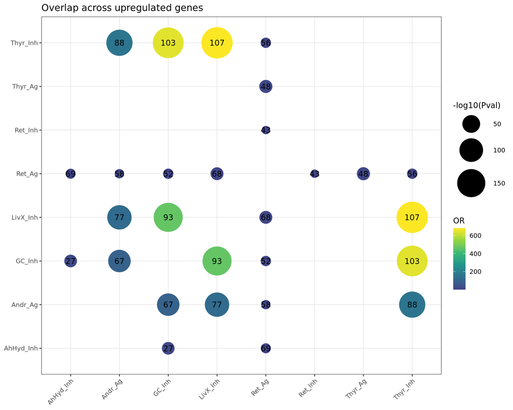

```r
Dot <- ggplot(ResSel, aes(DEGs, KBase, label=Numbers)) +
  geom_point(aes(size=-log10(Pval), col=OR)) +
  geom_text() +
  scale_size_continuous(range=c(2, 20), limits=c(2, round(-log10(min(ResSel$Pval)) + 0.5))) +
  scale_color_viridis_c(limits=c(1, round(max(ResSel$OR)+1)), begin=0.2) + xlab('') + ylab('') +
  theme_bw() +
  theme(axis.line = element_blank(), axis.title = element_blank(),
        axis.text.x = element_text(angle = 45, hjust = 1)) +
    ggtitle('Overlap across upregulated genes')

Dot
```

```r
ggsave(Dot, filename=paste0(OutputFolder, 'DotPlot_UpReg.pdf'), width=8, height=8)
```

## 5.3 Visualize overlap results selectively for retinoic, liverX, estrogen, thyroid

### Selection

Starting from already selected results, we identify only the ones related to the pathways of interest.

```r
Path <- c('Thyr_Ag', 'Thyr_Inh', 'Ret_Ag', 'Ret_Inh', 'Estr_Ag','Estr_Inh', 'LivX_Ag', 'LivX_Inh')
ResPath <- ResSel[ResSel$DEGs %in% Path & ResSel$KBase %in% Path, ]

ResPath
```

```
##        DEGs    KBase         OR          Pval Numbers
## 1    Ret_Ag  Thyr_Ag  10.951046  1.137907e-23      48
## 2    Ret_Ag Thyr_Inh   3.681121  7.635477e-13      56
## 5  LivX_Inh Thyr_Inh 680.541601 7.156443e-193     107
## 6   Thyr_Ag   Ret_Ag  10.951046  1.137907e-23      48
## 7  Thyr_Inh   Ret_Ag   3.681121  7.635477e-13      56
## 8   Ret_Inh   Ret_Ag   2.806160  1.482210e-07      43
## 11 LivX_Inh   Ret_Ag   5.787343  1.134878e-22      68
## 13   Ret_Ag  Ret_Inh   2.806160  1.482210e-07      43
## 23 Thyr_Inh LivX_Inh 680.541601 7.156443e-193     107
## 24   Ret_Ag LivX_Inh   5.787343  1.134878e-22      68
```

### DotPlot: visualization

```r
min(ResPath$Pval)
```

```
## [1] 7.156443e-193
```

```r
max(ResPath$OR)
```

```
## [1] 680.5416
```

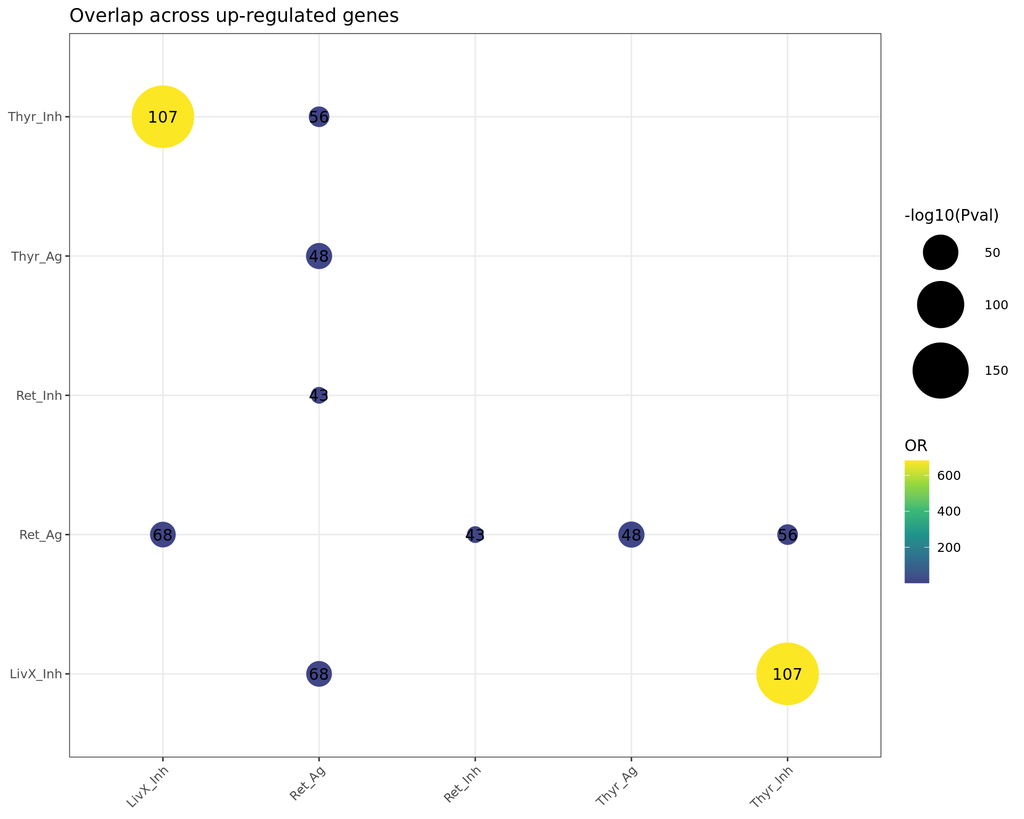

```r
Dot <- ggplot(ResPath, aes(DEGs, KBase, label=Numbers)) +
  geom_point(aes(size=-log10(Pval), col=OR)) +
  geom_text() +
  scale_size_continuous(range=c(2, 20), limits=c(2, round(-log10(min(ResSel$Pval)) + 0.5))) +
  scale_color_viridis_c(limits=c(1, round(max(ResSel$OR)+1)), begin=0.2) + xlab('') + ylab('') +
  theme_bw() +
  theme(axis.line = element_blank(), axis.title = element_blank(),
        axis.text.x = element_text(angle = 45, hjust = 1))+
  ggtitle('Overlap across up-regulated genes')


Dot
```

```r
ggsave(Dot, filename=paste0(OutputFolder, 'DotPlot_Upreg_Selected.pdf'), width=8, height=8)
```

# 6. Comparison across pathways: down-regulated genes

## 6.1 Perform the overlap

```r
DEGs_DownReg <- list(

  Thyr_Ag= row.names(DEA$Thyr$Agonist$DEGs[DEA$Thyr$Agonist$DEGs$log2FoldChange < 0, ]),
  Thyr_Inh= row.names(DEA$Thyr$Inhibitor$DEGs[DEA$Thyr$Inhibitor$DEGs$log2FoldChange < 0, ]),

  Ret_Ag= row.names(DEA$Ret$Agonist$DEGs[DEA$Ret$Agonist$DEGs$log2FoldChange < 0, ]),
  Ret_Inh= row.names(DEA$Ret$Inhibitor$DEGs[DEA$Ret$Inhibitor$DEGs$log2FoldChange < 0, ]),

  Estr_Ag= row.names(DEA$Estr$Agonist$DEGs[DEA$Estr$Agonist$DEGs$log2FoldChange < 0, ]),
  Estr_Inh= row.names(DEA$Estr$Inhibitor$DEGs[DEA$Estr$Inhibitor$DEGs$log2FoldChange < 0, ]),

  Andr_Ag= row.names(DEA$Andr$Agonist$DEGs[DEA$Andr$Agonist$DEGs$log2FoldChange < 0, ]),
  Andr_Inh= row.names(DEA$Andr$Inhibitor$DEGs[DEA$Andr$Inhibitor$DEGs$log2FoldChange < 0, ]),

  GC_Ag= row.names(DEA$GC$Agonist$DEGs[DEA$GC$Agonist$DEGs$log2FoldChange < 0, ]),
  GC_Inh= row.names(DEA$GC$Inhibitor$DEGs[DEA$GC$Inhibitor$DEGs$log2FoldChange < 0, ]),

  LivX_Ag= row.names(DEA$LivX$Agonist$DEGs[DEA$LivX$Agonist$DEGs$log2FoldChange < 0, ]),
  LivX_Inh= row.names(DEA$LivX$Inhibitor$DEGs[DEA$LivX$Inhibitor$DEGs$log2FoldChange < 0, ]),

  AhHyd_Ag= row.names(DEA$AhHyd$Agonist$DEGs[DEA$AhHyd$Agonist$DEGs$log2FoldChange < 0, ]),
  AhHyd_Inh= row.names(DEA$AhHyd$Inhibitor$DEGs[DEA$AhHyd$Inhibitor$DEGs$log2FoldChange < 0, ])

            )
```

```r
Universe <- row.names(DEA$Ret$Inhibitor$Res) %>% unique()
length(Universe)
```

```
## [1] 14305
```

```r
OvObj <- newGOM(DEGs_DownReg, DEGs_DownReg, genome.size=length(Universe))
print(OvObj)
## A GeneOverlapMatrix object:
## ###### Intersection ######
##           Thyr_Ag Thyr_Inh Ret_Ag Ret_Inh Estr_Ag Estr_Inh Andr_Ag Andr_Inh
## Thyr_Ag        69       30     36       7       2       20       2        2
## Thyr_Inh       30      257     83      12       0       36      19       12
## Ret_Ag         36       83   1108     191       0       25       5        6
## Ret_Inh         7       12    191     640       1       10       4        4
## Estr_Ag         2        0      0       1       3        0       0        1
## Estr_Inh       20       36     25      10       0       56       4        8
## Andr_Ag         2       19      5       4       0        4      45        0
## Andr_Inh        2       12      6       4       1        8       0       20
## GC_Ag           2        2      1       9       1        1       1        1
## GC_Inh         37      177    114      10       1       39      14       11
## LivX_Ag         1        1      0       6       1        1       0        0
## LivX_Inh       25      135     75       7       1       26      15        9
## AhHyd_Ag        5       11     12      19       0        8       2        7
## AhHyd_Inh       9       57     40      16       1       17       0       15
##           GC_Ag GC_Inh LivX_Ag LivX_Inh AhHyd_Ag AhHyd_Inh
## Thyr_Ag       2     37       1       25        5         9
## Thyr_Inh      2    177       1      135       11        57
## Ret_Ag        1    114       0       75       12        40
## Ret_Inh       9     10       6        7       19        16
## Estr_Ag       1      1       1        1        0         1
## Estr_Inh      1     39       1       26        8        17
## Andr_Ag       1     14       0       15        2         0
## Andr_Inh      1     11       0        9        7        15
## GC_Ag        13      3       3        3        0         7
## GC_Inh        3    294       2      155       12        57
## LivX_Ag       3      2       6        1        0         3
## LivX_Inh      3    155       1      202        7        39
## AhHyd_Ag      0     12       0        7       56        18
## AhHyd_Inh     7     57       3       39       18       134
## ###### P-value ######
##                 Thyr_Ag      Thyr_Inh       Ret_Ag      Ret_Inh      Estr_Ag
## Thyr_Ag   3.766883e-189  1.314468e-34 2.579072e-22 3.410822e-02 6.857653e-05
## Thyr_Inh   1.314468e-34  0.000000e+00 7.151751e-31 4.818121e-01 1.000000e+00
## Ret_Ag     2.579072e-22  7.151751e-31 0.000000e+00 3.312382e-65 1.000000e+00
## Ret_Inh    3.410822e-02  4.818121e-01 3.312382e-65 0.000000e+00 1.283120e-01
## Estr_Ag    6.857653e-05  1.000000e+00 1.000000e+00 1.283120e-01 2.050117e-12
## Estr_Inh   1.546010e-33  6.684890e-50 6.992332e-14 1.652791e-04 1.000000e+00
## Andr_Ag    1.986370e-02  5.628515e-22 2.675348e-01 1.408049e-01 1.000000e+00
## Andr_Inh   4.118950e-03  9.704536e-17 3.205604e-03 1.084916e-02 4.188769e-03
## GC_Ag      1.728186e-03  2.201011e-02 6.495414e-01 4.137255e-10 2.724033e-03
## GC_Inh     9.932654e-45 4.525907e-261 1.621225e-51 8.527122e-01 6.040239e-02
## LivX_Ag    2.859911e-02  1.030846e-01 1.000000e+00 7.841517e-09 1.257861e-03
## LivX_Inh   2.962314e-29 7.883616e-201 1.471045e-32 8.047628e-01 4.177030e-02
## AhHyd_Ag   7.114372e-06  3.705275e-09 1.007141e-03 1.592664e-12 1.000000e+00
## AhHyd_Inh  1.492924e-08  4.969385e-65 3.382033e-14 3.196646e-04 2.784157e-02
##                Estr_Inh       Andr_Ag     Andr_Inh        GC_Ag        GC_Inh
## Thyr_Ag    1.546010e-33  1.986370e-02 4.118950e-03 1.728186e-03  9.932654e-45
## Thyr_Inh   6.684890e-50  5.628515e-22 9.704536e-17 2.201011e-02 4.525907e-261
## Ret_Ag     6.992332e-14  2.675348e-01 3.205604e-03 6.495414e-01  1.621225e-51
## Ret_Inh    1.652791e-04  1.408049e-01 1.084916e-02 4.137255e-10  8.527122e-01
## Estr_Ag    1.000000e+00  1.000000e+00 4.188769e-03 2.724033e-03  6.040239e-02
## Estr_Inh  1.553685e-158  2.784958e-05 3.977371e-15 4.973331e-02  8.701825e-54
## Andr_Ag    2.784958e-05 1.291057e-131 1.000000e+00 4.014828e-02  1.660533e-13
## Andr_Inh   3.977371e-15  1.000000e+00 1.914866e-65 1.803127e-02  3.269870e-14
## GC_Ag      4.973331e-02  4.014828e-02 1.803127e-02 5.960832e-45  2.109142e-03
## GC_Inh     8.701825e-54  1.660533e-13 3.269870e-14 2.109142e-03  0.000000e+00
## LivX_Ag    2.326364e-02  1.000000e+00 1.000000e+00 1.170823e-08  5.978819e-03
## LivX_Inh   6.967515e-34  2.492156e-17 2.742714e-12 7.147365e-04 1.370752e-237
## AhHyd_Ag   4.027221e-11  1.337955e-02 7.119400e-13 1.000000e+00  1.131389e-09
## AhHyd_Inh  8.339853e-22  1.000000e+00 2.497908e-27 8.850269e-12  2.156529e-61
##                LivX_Ag      LivX_Inh      AhHyd_Ag    AhHyd_Inh
## Thyr_Ag   2.859911e-02  2.962314e-29  7.114372e-06 1.492924e-08
## Thyr_Inh  1.030846e-01 7.883616e-201  3.705275e-09 4.969385e-65
## Ret_Ag    1.000000e+00  1.471045e-32  1.007141e-03 3.382033e-14
## Ret_Inh   7.841517e-09  8.047628e-01  1.592664e-12 3.196646e-04
## Estr_Ag   1.257861e-03  4.177030e-02  1.000000e+00 2.784157e-02
## Estr_Inh  2.326364e-02  6.967515e-34  4.027221e-11 8.339853e-22
## Andr_Ag   1.000000e+00  2.492156e-17  1.337955e-02 1.000000e+00
## Andr_Inh  1.000000e+00  2.742714e-12  7.119400e-13 2.497908e-27
## GC_Ag     1.170823e-08  7.147365e-04  1.000000e+00 8.850269e-12
## GC_Inh    5.978819e-03 1.370752e-237  1.131389e-09 2.156529e-61
## LivX_Ag   8.411255e-23  8.180412e-02  1.000000e+00 1.574745e-05
## LivX_Inh  8.180412e-02  0.000000e+00  1.302391e-05 4.722935e-41
## AhHyd_Ag  1.000000e+00  1.302391e-05 1.553685e-158 1.493590e-23
## AhHyd_Inh 1.574745e-05  4.722935e-41  1.493590e-23 0.000000e+00
## ###### Odds Ratio ######
##              Thyr_Ag   Thyr_Inh     Ret_Ag    Ret_Inh    Estr_Ag   Estr_Inh
## Thyr_Ag          Inf  47.389921 13.3903265  2.4260223  419.58790 160.468876
## Thyr_Inh   47.389921        Inf  6.0580526  1.0466803    0.00000 113.747546
## Ret_Ag     13.390327   6.058053        Inf  5.9130615    0.00000   9.800973
## Ret_Inh     2.426022   1.046680  5.9130615        Inf   10.68590   4.698151
## Estr_Ag   419.587900   0.000000  0.0000000 10.6858965        Inf   0.000000
## Estr_Inh  160.468876 113.747546  9.8009726  4.6981515    0.00000        Inf
## Andr_Ag     9.846678  42.984396  1.4909839  2.0897197    0.00000  26.626652
## Andr_Inh   23.529156  85.721173  5.1257938  5.3638099  369.72647 195.929068
## GC_Ag      38.505367  10.000938  0.9925479 48.6600606  572.42312  21.536778
## GC_Inh     62.681002 261.728337  8.2914649  0.7478817   23.87832 125.623513
## LivX_Ag    41.741898  10.961044  0.0000000        Inf 1380.29024  51.615824
## LivX_Inh   45.061599 229.219257  7.4697454  0.7638911   35.02564  69.118348
## AhHyd_Ag   21.699494  13.908978  3.2725273 11.2605735    0.00000  49.166593
## AhHyd_Inh  16.917689  51.576644  5.2194405  2.9433413   53.12525  52.500274
##             Andr_Ag   Andr_Inh        GC_Ag      GC_Inh    LivX_Ag    LivX_Inh
## Thyr_Ag    9.846678  23.529156   38.5053671  62.6810015   41.74190  45.0615986
## Thyr_Inh  42.984396  85.721173   10.0009384 261.7283374   10.96104 229.2192571
## Ret_Ag     1.490984   5.125794    0.9925479   8.2914649    0.00000   7.4697454
## Ret_Inh    2.089720   5.363810   48.6600606   0.7478817        Inf   0.7638911
## Estr_Ag    0.000000 369.726466  572.4231226  23.8783153 1380.29024  35.0256447
## Estr_Inh  26.626652 195.929068   21.5367783 125.6235132   51.61582  69.1183483
## Andr_Ag         Inf   0.000000   26.9525489  22.5242987    0.00000  37.5690728
## Andr_Inh   0.000000        Inf   62.3652674  60.4186984    0.00000  59.5905220
## GC_Ag     26.952549  62.365267          Inf  14.4293865 1338.85419  21.2101381
## GC_Inh    22.524299  60.418698   14.4293865         Inf   23.95577 328.9124164
## LivX_Ag    0.000000   0.000000 1338.8541918  23.9557729        Inf  14.0229318
## LivX_Inh  37.569073  59.590522   21.2101381 328.9124164   14.02293         Inf
## AhHyd_Ag  12.226893 155.435109    0.0000000  13.4932391    0.00000  10.2925182
## AhHyd_Inh  0.000000 353.654463  129.2016419  43.4566049  108.03365  35.2301826
##             AhHyd_Ag  AhHyd_Inh
## Thyr_Ag    21.699494  16.917689
## Thyr_Inh   13.908978  51.576644
## Ret_Ag      3.272527   5.219441
## Ret_Inh    11.260574   2.943341
## Estr_Ag     0.000000  53.125252
## Estr_Inh   49.166593  52.500274
## Andr_Ag    12.226893   0.000000
## Andr_Inh  155.435109 353.654463
## GC_Ag       0.000000 129.201642
## GC_Inh     13.493239  43.456605
## LivX_Ag     0.000000 108.033649
## LivX_Inh   10.292518  35.230183
## AhHyd_Ag         Inf  57.657098
## AhHyd_Inh  57.657098        Inf
## ###### Jaccard Index ######
##              Thyr_Ag    Thyr_Inh       Ret_Ag     Ret_Inh     Estr_Ag
## Thyr_Ag   1.00000000 0.101351351 0.0315512708 0.009971510 0.028571429
## Thyr_Inh  0.10135135 1.000000000 0.0647425897 0.013559322 0.000000000
## Ret_Ag    0.03155127 0.064742590 1.0000000000 0.122671805 0.000000000
## Ret_Inh   0.00997151 0.013559322 0.1226718048 1.000000000 0.001557632
## Estr_Ag   0.02857143 0.000000000 0.0000000000 0.001557632 1.000000000
## Estr_Inh  0.19047619 0.129963899 0.0219490781 0.014577259 0.000000000
## Andr_Ag   0.01785714 0.067137809 0.0043554007 0.005873715 0.000000000
## Andr_Inh  0.02298851 0.045283019 0.0053475936 0.006097561 0.045454545
## GC_Ag     0.02500000 0.007462687 0.0008928571 0.013975155 0.066666667
## GC_Inh    0.11349693 0.473262032 0.0885093168 0.010822511 0.003378378
## LivX_Ag   0.01351351 0.003816794 0.0000000000 0.009375000 0.125000000
## LivX_Inh  0.10162602 0.416666667 0.0607287449 0.008383234 0.004901961
## AhHyd_Ag  0.04166667 0.036423841 0.0104166667 0.028064993 0.000000000
## AhHyd_Inh 0.04639175 0.170658683 0.0332778702 0.021108179 0.007352941
##             Estr_Inh     Andr_Ag    Andr_Inh        GC_Ag      GC_Inh
## Thyr_Ag   0.19047619 0.017857143 0.022988506 0.0250000000 0.113496933
## Thyr_Inh  0.12996390 0.067137809 0.045283019 0.0074626866 0.473262032
## Ret_Ag    0.02194908 0.004355401 0.005347594 0.0008928571 0.088509317
## Ret_Inh   0.01457726 0.005873715 0.006097561 0.0139751553 0.010822511
## Estr_Ag   0.00000000 0.000000000 0.045454545 0.0666666667 0.003378378
## Estr_Inh  1.00000000 0.041237113 0.117647059 0.0147058824 0.125401929
## Andr_Ag   0.04123711 1.000000000 0.000000000 0.0175438596 0.043076923
## Andr_Inh  0.11764706 0.000000000 1.000000000 0.0312500000 0.036303630
## GC_Ag     0.01470588 0.017543860 0.031250000 1.0000000000 0.009868421
## GC_Inh    0.12540193 0.043076923 0.036303630 0.0098684211 1.000000000
## LivX_Ag   0.01639344 0.000000000 0.000000000 0.1875000000 0.006711409
## LivX_Inh  0.11206897 0.064655172 0.042253521 0.0141509434 0.454545455
## AhHyd_Ag  0.07692308 0.020202020 0.101449275 0.0000000000 0.035502959
## AhHyd_Inh 0.09826590 0.000000000 0.107913669 0.0500000000 0.153638814
##               LivX_Ag    LivX_Inh   AhHyd_Ag   AhHyd_Inh
## Thyr_Ag   0.013513514 0.101626016 0.04166667 0.046391753
## Thyr_Inh  0.003816794 0.416666667 0.03642384 0.170658683
## Ret_Ag    0.000000000 0.060728745 0.01041667 0.033277870
## Ret_Inh   0.009375000 0.008383234 0.02806499 0.021108179
## Estr_Ag   0.125000000 0.004901961 0.00000000 0.007352941
## Estr_Inh  0.016393443 0.112068966 0.07692308 0.098265896
## Andr_Ag   0.000000000 0.064655172 0.02020202 0.000000000
## Andr_Inh  0.000000000 0.042253521 0.10144928 0.107913669
## GC_Ag     0.187500000 0.014150943 0.00000000 0.050000000
## GC_Inh    0.006711409 0.454545455 0.03550296 0.153638814
## LivX_Ag   1.000000000 0.004830918 0.00000000 0.021897810
## LivX_Inh  0.004830918 1.000000000 0.02788845 0.131313131
## AhHyd_Ag  0.000000000 0.027888446 1.00000000 0.104651163
## AhHyd_Inh 0.021897810 0.131313131 0.10465116 1.000000000
```

```r
getMatrix(OvObj, name='intersection')
```

```
##           Thyr_Ag Thyr_Inh Ret_Ag Ret_Inh Estr_Ag Estr_Inh Andr_Ag Andr_Inh
## Thyr_Ag        69       30     36       7       2       20       2        2
## Thyr_Inh       30      257     83      12       0       36      19       12
## Ret_Ag         36       83   1108     191       0       25       5        6
## Ret_Inh         7       12    191     640       1       10       4        4
## Estr_Ag         2        0      0       1       3        0       0        1
## Estr_Inh       20       36     25      10       0       56       4        8
## Andr_Ag         2       19      5       4       0        4      45        0
## Andr_Inh        2       12      6       4       1        8       0       20
## GC_Ag           2        2      1       9       1        1       1        1
## GC_Inh         37      177    114      10       1       39      14       11
## LivX_Ag         1        1      0       6       1        1       0        0
## LivX_Inh       25      135     75       7       1       26      15        9
## AhHyd_Ag        5       11     12      19       0        8       2        7
## AhHyd_Inh       9       57     40      16       1       17       0       15
##           GC_Ag GC_Inh LivX_Ag LivX_Inh AhHyd_Ag AhHyd_Inh
## Thyr_Ag       2     37       1       25        5         9
## Thyr_Inh      2    177       1      135       11        57
## Ret_Ag        1    114       0       75       12        40
## Ret_Inh       9     10       6        7       19        16
## Estr_Ag       1      1       1        1        0         1
## Estr_Inh      1     39       1       26        8        17
## Andr_Ag       1     14       0       15        2         0
## Andr_Inh      1     11       0        9        7        15
## GC_Ag        13      3       3        3        0         7
## GC_Inh        3    294       2      155       12        57
## LivX_Ag       3      2       6        1        0         3
## LivX_Inh      3    155       1      202        7        39
## AhHyd_Ag      0     12       0        7       56        18
## AhHyd_Inh     7     57       3       39       18       134
```

```r
getMatrix(OvObj, name='pval')
```

```
##                 Thyr_Ag      Thyr_Inh       Ret_Ag      Ret_Inh      Estr_Ag
## Thyr_Ag   3.766883e-189  1.314468e-34 2.579072e-22 3.410822e-02 6.857653e-05
## Thyr_Inh   1.314468e-34  0.000000e+00 7.151751e-31 4.818121e-01 1.000000e+00
## Ret_Ag     2.579072e-22  7.151751e-31 0.000000e+00 3.312382e-65 1.000000e+00
## Ret_Inh    3.410822e-02  4.818121e-01 3.312382e-65 0.000000e+00 1.283120e-01
## Estr_Ag    6.857653e-05  1.000000e+00 1.000000e+00 1.283120e-01 2.050117e-12
## Estr_Inh   1.546010e-33  6.684890e-50 6.992332e-14 1.652791e-04 1.000000e+00
## Andr_Ag    1.986370e-02  5.628515e-22 2.675348e-01 1.408049e-01 1.000000e+00
## Andr_Inh   4.118950e-03  9.704536e-17 3.205604e-03 1.084916e-02 4.188769e-03
## GC_Ag      1.728186e-03  2.201011e-02 6.495414e-01 4.137255e-10 2.724033e-03
## GC_Inh     9.932654e-45 4.525907e-261 1.621225e-51 8.527122e-01 6.040239e-02
## LivX_Ag    2.859911e-02  1.030846e-01 1.000000e+00 7.841517e-09 1.257861e-03
## LivX_Inh   2.962314e-29 7.883616e-201 1.471045e-32 8.047628e-01 4.177030e-02
## AhHyd_Ag   7.114372e-06  3.705275e-09 1.007141e-03 1.592664e-12 1.000000e+00
## AhHyd_Inh  1.492924e-08  4.969385e-65 3.382033e-14 3.196646e-04 2.784157e-02
##                Estr_Inh       Andr_Ag     Andr_Inh        GC_Ag        GC_Inh
## Thyr_Ag    1.546010e-33  1.986370e-02 4.118950e-03 1.728186e-03  9.932654e-45
## Thyr_Inh   6.684890e-50  5.628515e-22 9.704536e-17 2.201011e-02 4.525907e-261
## Ret_Ag     6.992332e-14  2.675348e-01 3.205604e-03 6.495414e-01  1.621225e-51
## Ret_Inh    1.652791e-04  1.408049e-01 1.084916e-02 4.137255e-10  8.527122e-01
## Estr_Ag    1.000000e+00  1.000000e+00 4.188769e-03 2.724033e-03  6.040239e-02
## Estr_Inh  1.553685e-158  2.784958e-05 3.977371e-15 4.973331e-02  8.701825e-54
## Andr_Ag    2.784958e-05 1.291057e-131 1.000000e+00 4.014828e-02  1.660533e-13
## Andr_Inh   3.977371e-15  1.000000e+00 1.914866e-65 1.803127e-02  3.269870e-14
## GC_Ag      4.973331e-02  4.014828e-02 1.803127e-02 5.960832e-45  2.109142e-03
## GC_Inh     8.701825e-54  1.660533e-13 3.269870e-14 2.109142e-03  0.000000e+00
## LivX_Ag    2.326364e-02  1.000000e+00 1.000000e+00 1.170823e-08  5.978819e-03
## LivX_Inh   6.967515e-34  2.492156e-17 2.742714e-12 7.147365e-04 1.370752e-237
## AhHyd_Ag   4.027221e-11  1.337955e-02 7.119400e-13 1.000000e+00  1.131389e-09
## AhHyd_Inh  8.339853e-22  1.000000e+00 2.497908e-27 8.850269e-12  2.156529e-61
##                LivX_Ag      LivX_Inh      AhHyd_Ag    AhHyd_Inh
## Thyr_Ag   2.859911e-02  2.962314e-29  7.114372e-06 1.492924e-08
## Thyr_Inh  1.030846e-01 7.883616e-201  3.705275e-09 4.969385e-65
## Ret_Ag    1.000000e+00  1.471045e-32  1.007141e-03 3.382033e-14
## Ret_Inh   7.841517e-09  8.047628e-01  1.592664e-12 3.196646e-04
## Estr_Ag   1.257861e-03  4.177030e-02  1.000000e+00 2.784157e-02
## Estr_Inh  2.326364e-02  6.967515e-34  4.027221e-11 8.339853e-22
## Andr_Ag   1.000000e+00  2.492156e-17  1.337955e-02 1.000000e+00
## Andr_Inh  1.000000e+00  2.742714e-12  7.119400e-13 2.497908e-27
## GC_Ag     1.170823e-08  7.147365e-04  1.000000e+00 8.850269e-12
## GC_Inh    5.978819e-03 1.370752e-237  1.131389e-09 2.156529e-61
## LivX_Ag   8.411255e-23  8.180412e-02  1.000000e+00 1.574745e-05
## LivX_Inh  8.180412e-02  0.000000e+00  1.302391e-05 4.722935e-41
## AhHyd_Ag  1.000000e+00  1.302391e-05 1.553685e-158 1.493590e-23
## AhHyd_Inh 1.574745e-05  4.722935e-41  1.493590e-23 0.000000e+00
```

```r
getMatrix(OvObj, name='odds.ratio')
```

```
##              Thyr_Ag   Thyr_Inh     Ret_Ag    Ret_Inh    Estr_Ag   Estr_Inh
## Thyr_Ag          Inf  47.389921 13.3903265  2.4260223  419.58790 160.468876
## Thyr_Inh   47.389921        Inf  6.0580526  1.0466803    0.00000 113.747546
## Ret_Ag     13.390327   6.058053        Inf  5.9130615    0.00000   9.800973
## Ret_Inh     2.426022   1.046680  5.9130615        Inf   10.68590   4.698151
## Estr_Ag   419.587900   0.000000  0.0000000 10.6858965        Inf   0.000000
## Estr_Inh  160.468876 113.747546  9.8009726  4.6981515    0.00000        Inf
## Andr_Ag     9.846678  42.984396  1.4909839  2.0897197    0.00000  26.626652
## Andr_Inh   23.529156  85.721173  5.1257938  5.3638099  369.72647 195.929068
## GC_Ag      38.505367  10.000938  0.9925479 48.6600606  572.42312  21.536778
## GC_Inh     62.681002 261.728337  8.2914649  0.7478817   23.87832 125.623513
## LivX_Ag    41.741898  10.961044  0.0000000        Inf 1380.29024  51.615824
## LivX_Inh   45.061599 229.219257  7.4697454  0.7638911   35.02564  69.118348
## AhHyd_Ag   21.699494  13.908978  3.2725273 11.2605735    0.00000  49.166593
## AhHyd_Inh  16.917689  51.576644  5.2194405  2.9433413   53.12525  52.500274
##             Andr_Ag   Andr_Inh        GC_Ag      GC_Inh    LivX_Ag    LivX_Inh
## Thyr_Ag    9.846678  23.529156   38.5053671  62.6810015   41.74190  45.0615986
## Thyr_Inh  42.984396  85.721173   10.0009384 261.7283374   10.96104 229.2192571
## Ret_Ag     1.490984   5.125794    0.9925479   8.2914649    0.00000   7.4697454
## Ret_Inh    2.089720   5.363810   48.6600606   0.7478817        Inf   0.7638911
## Estr_Ag    0.000000 369.726466  572.4231226  23.8783153 1380.29024  35.0256447
## Estr_Inh  26.626652 195.929068   21.5367783 125.6235132   51.61582  69.1183483
## Andr_Ag         Inf   0.000000   26.9525489  22.5242987    0.00000  37.5690728
## Andr_Inh   0.000000        Inf   62.3652674  60.4186984    0.00000  59.5905220
## GC_Ag     26.952549  62.365267          Inf  14.4293865 1338.85419  21.2101381
## GC_Inh    22.524299  60.418698   14.4293865         Inf   23.95577 328.9124164
## LivX_Ag    0.000000   0.000000 1338.8541918  23.9557729        Inf  14.0229318
## LivX_Inh  37.569073  59.590522   21.2101381 328.9124164   14.02293         Inf
## AhHyd_Ag  12.226893 155.435109    0.0000000  13.4932391    0.00000  10.2925182
## AhHyd_Inh  0.000000 353.654463  129.2016419  43.4566049  108.03365  35.2301826
##             AhHyd_Ag  AhHyd_Inh
## Thyr_Ag    21.699494  16.917689
## Thyr_Inh   13.908978  51.576644
## Ret_Ag      3.272527   5.219441
## Ret_Inh    11.260574   2.943341
## Estr_Ag     0.000000  53.125252
## Estr_Inh   49.166593  52.500274
## Andr_Ag    12.226893   0.000000
## Andr_Inh  155.435109 353.654463
## GC_Ag       0.000000 129.201642
## GC_Inh     13.493239  43.456605
## LivX_Ag     0.000000 108.033649
## LivX_Inh   10.292518  35.230183
## AhHyd_Ag         Inf  57.657098
## AhHyd_Inh  57.657098        Inf
```

## 6.2 Visualize overlap results

**DotPlot: data preparation**

```r
OR <- data.frame(getMatrix(OvObj, name='odds.ratio'))
OR$DEGs <- row.names(OR)
OR <- gather(OR, 'KBase', 'OR', -DEGs)
PVAL <- data.frame(getMatrix(OvObj, name='pval'))
PVAL$DEGs <- row.names(PVAL)
PVAL <- gather(PVAL, 'KBase', 'PVal', -DEGs)
NUM <- data.frame(getMatrix(OvObj, name='intersection'))
NUM$DEGs <- row.names(NUM)
NUM <- gather(NUM, 'KBase', 'Numbers', -DEGs)
if(! identical(OR$DEGs, PVAL$DEGs)){
  stop('Inconsistecy')
}
if(! identical(OR$DEGs, NUM$DEGs)){
  stop('Inconsistecy')
}
if(! identical(OR$KBase, NUM$KBase)){
  stop('Inconsistecy')
}
if(! identical(OR$KBase, NUM$KBase)){
  stop('Inconsistecy')
}
Res <- mutate(OR, Pval=PVAL$PVal) %>% mutate(Numbers=NUM$Numbers)
Res
```

```
##          DEGs     KBase           OR          Pval Numbers
## 1     Thyr_Ag   Thyr_Ag          Inf 3.766883e-189      69
## 2    Thyr_Inh   Thyr_Ag   47.3899209  1.314468e-34      30
## 3      Ret_Ag   Thyr_Ag   13.3903265  2.579072e-22      36
## 4     Ret_Inh   Thyr_Ag    2.4260223  3.410822e-02       7
## 5     Estr_Ag   Thyr_Ag  419.5878999  6.857653e-05       2
## 6    Estr_Inh   Thyr_Ag  160.4688759  1.546010e-33      20
## 7     Andr_Ag   Thyr_Ag    9.8466778  1.986370e-02       2
## 8    Andr_Inh   Thyr_Ag   23.5291565  4.118950e-03       2
## 9       GC_Ag   Thyr_Ag   38.5053671  1.728186e-03       2
## 10     GC_Inh   Thyr_Ag   62.6810015  9.932654e-45      37
## 11    LivX_Ag   Thyr_Ag   41.7418977  2.859911e-02       1
## 12   LivX_Inh   Thyr_Ag   45.0615986  2.962314e-29      25
## 13   AhHyd_Ag   Thyr_Ag   21.6994936  7.114372e-06       5
## 14  AhHyd_Inh   Thyr_Ag   16.9176895  1.492924e-08       9
```

[output cut: 182 more lines]

```r
ResMod <- Res

ResMod[ResMod$DEGs == ResMod$KBase, ]$OR <- 1
ResMod[ResMod$DEGs == ResMod$KBase, ]$Pval <- 1

ResMod
```

```
##          DEGs     KBase           OR          Pval Numbers
## 1     Thyr_Ag   Thyr_Ag    1.0000000  1.000000e+00      69
## 2    Thyr_Inh   Thyr_Ag   47.3899209  1.314468e-34      30
## 3      Ret_Ag   Thyr_Ag   13.3903265  2.579072e-22      36
## 4     Ret_Inh   Thyr_Ag    2.4260223  3.410822e-02       7
## 5     Estr_Ag   Thyr_Ag  419.5878999  6.857653e-05       2
## 6    Estr_Inh   Thyr_Ag  160.4688759  1.546010e-33      20
## 7     Andr_Ag   Thyr_Ag    9.8466778  1.986370e-02       2
## 8    Andr_Inh   Thyr_Ag   23.5291565  4.118950e-03       2
## 9       GC_Ag   Thyr_Ag   38.5053671  1.728186e-03       2
## 10     GC_Inh   Thyr_Ag   62.6810015  9.932654e-45      37
## 11    LivX_Ag   Thyr_Ag   41.7418977  2.859911e-02       1
## 12   LivX_Inh   Thyr_Ag   45.0615986  2.962314e-29      25
## 13   AhHyd_Ag   Thyr_Ag   21.6994936  7.114372e-06       5
## 14  AhHyd_Inh   Thyr_Ag   16.9176895  1.492924e-08       9
```

[output cut: 182 more lines]

### DotPlot: visualization

I select as significant overlaps having an OR > 2 and at least 25 overlapping genes. Dots are shown for PVals < 0.01 (set in the plot). Max value in the plot must be set according to minimum PVal to avoid dots not to be shown.

```r
cols <- viridis::cividis(100)[1:80]
ResSel <- dplyr::filter(ResMod, OR > 2) %>% dplyr::filter(Numbers > 25)
min(ResSel$Pval)
```

```
## [1] 4.525907e-261
```

```r
max(ResSel$OR)
```

```
## [1] 328.9124
```

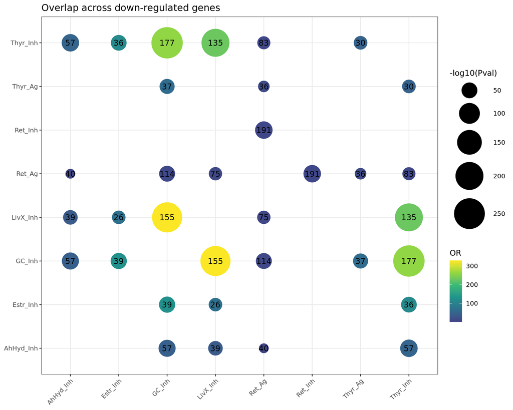

```r
Dot <- ggplot(ResSel, aes(DEGs, KBase, label=Numbers)) +
  geom_point(aes(size=-log10(Pval), col=OR)) +
  geom_text() +
  scale_size_continuous(range=c(2, 20), limits=c(2, round(-log10(min(ResSel$Pval)) + 0.5))) +
  scale_color_viridis_c(limits=c(1, round(max(ResSel$OR)+1)), begin=0.2) + xlab('') + ylab('') +
  theme_bw() +
  theme(axis.line = element_blank(), axis.title = element_blank(),
        axis.text.x = element_text(angle = 45, hjust = 1)) +
    ggtitle('Overlap across down-regulated genes')

Dot
```

```r
ggsave(Dot, filename=paste0(OutputFolder, 'DotPlot_DownReg.pdf'), width=8, height=8)
```

## 6.3 Visualize overlap results selectively for retinoic, liverX, estrogen, thyroid

### Selection

```r
Path <- c('Thyr_Ag', 'Thyr_Inh', 'Ret_Ag', 'Ret_Inh', 'Estr_Ag','Estr_Inh', 'LivX_Ag', 'LivX_Inh')
ResPath <- ResSel[ResSel$DEGs %in% Path & ResSel$KBase %in% Path, ]

ResPath
```

```
##        DEGs    KBase         OR          Pval Numbers
## 1  Thyr_Inh  Thyr_Ag  47.389921  1.314468e-34      30
## 2    Ret_Ag  Thyr_Ag  13.390327  2.579072e-22      36
## 4   Thyr_Ag Thyr_Inh  47.389921  1.314468e-34      30
## 5    Ret_Ag Thyr_Inh   6.058053  7.151751e-31      83
## 6  Estr_Inh Thyr_Inh 113.747546  6.684890e-50      36
## 8  LivX_Inh Thyr_Inh 229.219257 7.883616e-201     135
## 10  Thyr_Ag   Ret_Ag  13.390327  2.579072e-22      36
## 11 Thyr_Inh   Ret_Ag   6.058053  7.151751e-31      83
## 12  Ret_Inh   Ret_Ag   5.913061  3.312382e-65     191
## 14 LivX_Inh   Ret_Ag   7.469745  1.471045e-32      75
## 16   Ret_Ag  Ret_Inh   5.913061  3.312382e-65     191
## 17 Thyr_Inh Estr_Inh 113.747546  6.684890e-50      36
## 19 LivX_Inh Estr_Inh  69.118348  6.967515e-34      26
## 26 Thyr_Inh LivX_Inh 229.219257 7.883616e-201     135
## 27   Ret_Ag LivX_Inh   7.469745  1.471045e-32      75
## 28 Estr_Inh LivX_Inh  69.118348  6.967515e-34      26
```

### DotPlot: visualization

```r
cols <- viridis::cividis(100)[1:80]
ResPath <- dplyr::filter(ResPath, OR > 2) %>% dplyr::filter(Numbers > 25)
min(ResPath$Pval)
```

```
## [1] 7.883616e-201
```

```r
max(ResPath$OR)
```

```
## [1] 229.2193
```

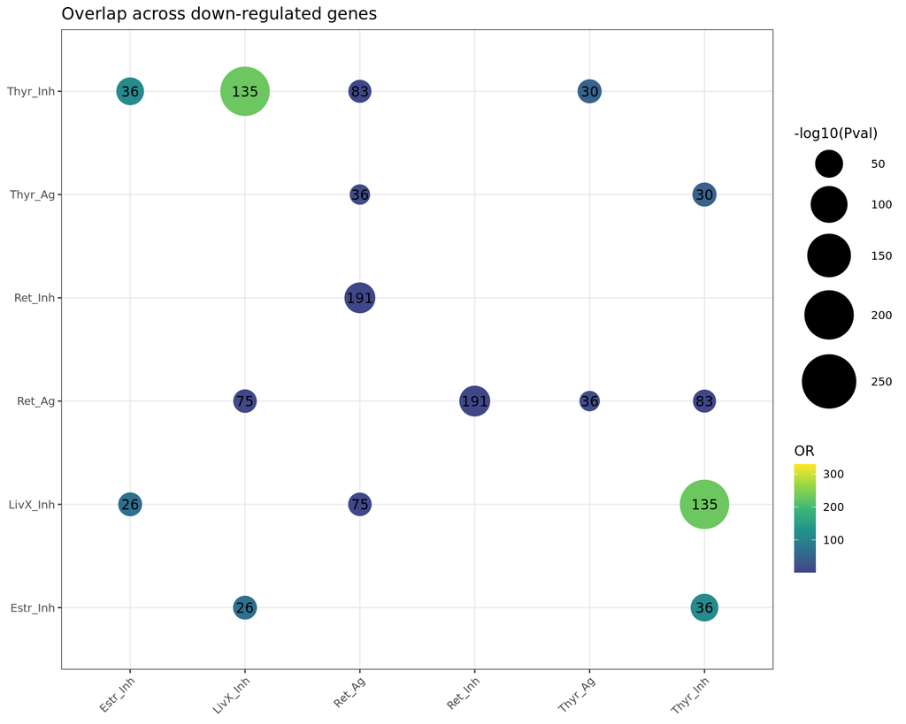

```r
Dot <- ggplot(ResPath, aes(DEGs, KBase, label=Numbers)) +
  geom_point(aes(size=-log10(Pval), col=OR)) +
  geom_text() +
  scale_size_continuous(range=c(2, 20), limits=c(2, round(-log10(min(ResSel$Pval)) + 0.5))) +
  scale_color_viridis_c(limits=c(1, round(max(ResSel$OR)+1)), begin=0.2) + xlab('') + ylab('') +
  theme_bw() +
  theme(axis.line = element_blank(), axis.title = element_blank(),
        axis.text.x = element_text(angle = 45, hjust = 1))+
  ggtitle('Overlap across down-regulated genes')


Dot
```

```r
ggsave(Dot, filename=paste0(OutputFolder, 'DotPlot_DownReg_Selected.pdf'), width=8, height=8)
```

# 7. Comparison across pathways: Agonist versus Inhibitor analysis

## 7.1 Perform Overlap

```r
DEGs_AgvsInh <- list(

  Thyr_AgvsInh_Up= row.names(DEA$Thyr$AgvsInh$DEGs[DEA$Thyr$AgvsInh$DEGs$log2FoldChange > 0, ]),
  Thyr_AgvsInh_Down= row.names(DEA$Thyr$AgvsInh$DEGs[DEA$Thyr$AgvsInh$DEGs$log2FoldChange < 0, ]),

  Ret_AgvsInh_Up= row.names(DEA$Ret$AgvsInh$DEGs[DEA$Ret$AgvsInh$DEGs$log2FoldChange > 0, ]),
  Ret_AgvsInh_Down= row.names(DEA$Ret$AgvsInh$DEGs[DEA$Ret$AgvsInh$DEGs$log2FoldChange < 0, ]),

  Estr_AgvsInh_Up= row.names(DEA$Estr$AgvsInh$DEGs[DEA$Estr$AgvsInh$DEGs$log2FoldChange > 0, ]),
  Estr_AgvsInh_Down= row.names(DEA$Estr$AgvsInh$DEGs[DEA$Estr$AgvsInh$DEGs$log2FoldChange < 0, ]),

  Andr_AgvsInh_Up= row.names(DEA$Andr$AgvsInh$DEGs[DEA$Andr$AgvsInh$DEGs$log2FoldChange > 0, ]),
  Andr_AgvsInh_Down= row.names(DEA$Andr$AgvsInh$DEGs[DEA$Andr$AgvsInh$DEGs$log2FoldChange < 0, ]),

  GC_AgvsInh_Up= row.names(DEA$GC$AgvsInh$DEGs[DEA$GC$AgvsInh$DEGs$log2FoldChange > 0, ]),
  GC_AgvsInh_Down= row.names(DEA$GC$AgvsInh$DEGs[DEA$GC$AgvsInh$DEGs$log2FoldChange < 0, ]),

  LivX_AgvsInh_Up= row.names(DEA$LivX$AgvsInh$DEGs[DEA$LivX$AgvsInh$DEGs$log2FoldChange > 0, ]),
  LivX_AgvsInh_Down= row.names(DEA$LivX$AgvsInh$DEGs[DEA$LivX$AgvsInh$DEGs$log2FoldChange < 0, ]),

  AhHyd_AgvsInh_Up= row.names(DEA$AhHyd$AgvsInh$DEGs[DEA$AhHyd$AgvsInh$DEGs$log2FoldChange > 0, ]),
  AhHyd_AgvsInh_Down= row.names(DEA$AhHyd$AgvsInh$DEGs[DEA$AhHyd$AgvsInh$DEGs$log2FoldChange < 0, ])

            )
```

```r
Universe <- row.names(DEA$Ret$Agonist$Res) %>% unique()
length(Universe)
```

```
## [1] 14305
```

```r
OvObj <- newGOM(DEGs_AgvsInh, DEGs_AgvsInh, genome.size=length(Universe))
#print(OvObj)
```

```r
getMatrix(OvObj, name='intersection')
```

```
##                    Thyr_AgvsInh_Up Thyr_AgvsInh_Down Ret_AgvsInh_Up
## Thyr_AgvsInh_Up                191                 0             79
## Thyr_AgvsInh_Down                0               133             35
## Ret_AgvsInh_Up                  79                35           2171
## Ret_AgvsInh_Down                45                24              0
## Estr_AgvsInh_Up                  8                 1             11
## Estr_AgvsInh_Down                0                13              3
## Andr_AgvsInh_Up                  4                77             97
## Andr_AgvsInh_Down               27                 3             46
## GC_AgvsInh_Up                   85                 0             29
## GC_AgvsInh_Down                  0                63             75
## LivX_AgvsInh_Up                 67                 1             29
## LivX_AgvsInh_Down                1                60            103
## AhHyd_AgvsInh_Up                 8                18             41
## AhHyd_AgvsInh_Down              11                 4            172
##                    Ret_AgvsInh_Down Estr_AgvsInh_Up Estr_AgvsInh_Down
## Thyr_AgvsInh_Up                  45               8                 0
## Thyr_AgvsInh_Down                24               1                13
## Ret_AgvsInh_Up                    0              11                 3
## Ret_AgvsInh_Down               1370              11                 4
## Estr_AgvsInh_Up                  11              32                 0
## Estr_AgvsInh_Down                 4               0                26
## Andr_AgvsInh_Up                  18               4                11
## Andr_AgvsInh_Down                89               2                 3
## GC_AgvsInh_Up                   167              18                 3
## GC_AgvsInh_Down                  14               0                12
## LivX_AgvsInh_Up                 129              11                 2
## LivX_AgvsInh_Down                12               0                14
## AhHyd_AgvsInh_Up                 18               3                 3
## AhHyd_AgvsInh_Down               31               1                 2
##                    Andr_AgvsInh_Up Andr_AgvsInh_Down GC_AgvsInh_Up
## Thyr_AgvsInh_Up                  4                27            85
## Thyr_AgvsInh_Down               77                 3             0
## Ret_AgvsInh_Up                  97                46            29
## Ret_AgvsInh_Down                18                89           167
## Estr_AgvsInh_Up                  4                 2            18
## Estr_AgvsInh_Down               11                 3             3
## Andr_AgvsInh_Up                325                 0             4
## Andr_AgvsInh_Down                0               225            66
## GC_AgvsInh_Up                    4                66           373
```

[output cut: 20 more lines]

```
##                    AhHyd_AgvsInh_Up AhHyd_AgvsInh_Down
## Thyr_AgvsInh_Up                   8                 11
## Thyr_AgvsInh_Down                18                  4
## Ret_AgvsInh_Up                   41                172
## Ret_AgvsInh_Down                 18                 31
## Estr_AgvsInh_Up                   3                  1
## Estr_AgvsInh_Down                 3                  2
## Andr_AgvsInh_Up                  44                  0
## Andr_AgvsInh_Down                 0                 59
## GC_AgvsInh_Up                     9                 26
## GC_AgvsInh_Down                  31                 10
## LivX_AgvsInh_Up                   8                 21
## LivX_AgvsInh_Down                29                 17
## AhHyd_AgvsInh_Up                110                  0
## AhHyd_AgvsInh_Down                0                280
```

```r
getMatrix(OvObj, name='pval')
```

```
##                    Thyr_AgvsInh_Up Thyr_AgvsInh_Down Ret_AgvsInh_Up
## Thyr_AgvsInh_Up       0.000000e+00      1.000000e+00   1.421630e-18
## Thyr_AgvsInh_Down     1.000000e+00      0.000000e+00   5.901433e-04
## Ret_AgvsInh_Up        1.421630e-18      5.901433e-04   0.000000e+00
## Ret_AgvsInh_Down      8.726946e-09      1.731715e-03   1.000000e+00
## Estr_AgvsInh_Up       6.974103e-09      2.586155e-01   5.653845e-03
## Estr_AgvsInh_Down     1.000000e+00      1.999327e-20   7.778992e-01
## Andr_AgvsInh_Up       6.342118e-01      1.019081e-93   8.941044e-12
## Andr_AgvsInh_Down     2.322727e-18      3.484756e-01   1.956813e-02
## GC_AgvsInh_Up         6.298575e-85      1.000000e+00   9.999957e-01
## GC_AgvsInh_Down       1.000000e+00      6.364375e-89   1.791092e-19
## LivX_AgvsInh_Up       6.733621e-66      9.358337e-01   9.966646e-01
## LivX_AgvsInh_Down     9.256038e-01      3.444565e-79   1.135165e-35
## AhHyd_AgvsInh_Up      1.118496e-04      8.043640e-18   1.043005e-08
## AhHyd_AgvsInh_Down    1.367533e-03      2.634182e-01   1.681532e-71
##                    Ret_AgvsInh_Down Estr_AgvsInh_Up Estr_AgvsInh_Down
## Thyr_AgvsInh_Up        8.726946e-09    6.974103e-09      1.000000e+00
## Thyr_AgvsInh_Down      1.731715e-03    2.586155e-01      1.999327e-20
## Ret_AgvsInh_Up         1.000000e+00    5.653845e-03      7.778992e-01
## Ret_AgvsInh_Down       0.000000e+00    1.154895e-04      2.343454e-01
## Estr_AgvsInh_Up        1.154895e-04    2.881573e-98      1.000000e+00
## Estr_AgvsInh_Down      2.343454e-01    1.000000e+00      3.739447e-82
## Andr_AgvsInh_Up        9.972662e-01    5.693650e-03      4.010907e-12
## Andr_AgvsInh_Down      9.213323e-34    8.982384e-02      7.644201e-03
## GC_AgvsInh_Up          5.706244e-73    6.985781e-21      2.933257e-02
## GC_AgvsInh_Down        7.694561e-01    1.000000e+00      4.816229e-17
## LivX_AgvsInh_Up        1.435075e-55    1.805373e-11      9.741783e-02
## LivX_AgvsInh_Down      9.622804e-01    1.000000e+00      3.200680e-20
## AhHyd_AgvsInh_Up       1.660658e-02    1.865553e-03      1.011205e-03
## AhHyd_AgvsInh_Down     2.214766e-01    4.691410e-01      9.126644e-02
##                    Andr_AgvsInh_Up Andr_AgvsInh_Down GC_AgvsInh_Up
## Thyr_AgvsInh_Up       6.342118e-01      2.322727e-18  6.298575e-85
## Thyr_AgvsInh_Down     1.019081e-93      3.484756e-01  1.000000e+00
## Ret_AgvsInh_Up        8.941044e-12      1.956813e-02  9.999957e-01
## Ret_AgvsInh_Down      9.972662e-01      9.213323e-34  5.706244e-73
## Estr_AgvsInh_Up       5.693650e-03      8.982384e-02  6.985781e-21
## Estr_AgvsInh_Down     4.010907e-12      7.644201e-03  2.933257e-02
## Andr_AgvsInh_Up       0.000000e+00      1.000000e+00  9.721261e-01
## Andr_AgvsInh_Down     1.000000e+00      0.000000e+00  1.917203e-51
## GC_AgvsInh_Up         9.721261e-01      1.917203e-51  0.000000e+00
```

[output cut: 20 more lines]

```
##                    AhHyd_AgvsInh_Up AhHyd_AgvsInh_Down
## Thyr_AgvsInh_Up        1.118496e-04       1.367533e-03
## Thyr_AgvsInh_Down      8.043640e-18       2.634182e-01
## Ret_AgvsInh_Up         1.043005e-08       1.681532e-71
## Ret_AgvsInh_Down       1.660658e-02       2.214766e-01
## Estr_AgvsInh_Up        1.865553e-03       4.691410e-01
## Estr_AgvsInh_Down      1.011205e-03       9.126644e-02
## Andr_AgvsInh_Up        7.366421e-44       1.000000e+00
## Andr_AgvsInh_Down      1.000000e+00       1.946507e-50
## GC_AgvsInh_Up          2.319710e-03       2.103207e-08
## GC_AgvsInh_Down        1.460928e-34       1.997478e-03
## LivX_AgvsInh_Up        1.817733e-03       2.855977e-07
## LivX_AgvsInh_Down      7.100713e-30       2.302002e-07
## AhHyd_AgvsInh_Up      1.904254e-279       1.000000e+00
## AhHyd_AgvsInh_Down     1.000000e+00       0.000000e+00
```

```r
getMatrix(OvObj, name='odds.ratio')
```

```
##                    Thyr_AgvsInh_Up Thyr_AgvsInh_Down Ret_AgvsInh_Up
## Thyr_AgvsInh_Up                Inf         0.0000000      4.0530055
## Thyr_AgvsInh_Down        0.0000000               Inf      2.0123753
## Ret_AgvsInh_Up           4.0530055         2.0123753            Inf
## Ret_AgvsInh_Down         2.9744832         2.0979815      0.0000000
## Estr_AgvsInh_Up         25.6461692         3.4551786      2.9371490
## Estr_AgvsInh_Down        0.0000000       117.3982815      0.7286571
## Andr_AgvsInh_Up          0.9191247        76.9388578      2.4419925
## Andr_AgvsInh_Down       11.5631303         1.4500290      1.4457123
## GC_AgvsInh_Up           38.4467168         0.0000000      0.4640398
## GC_AgvsInh_Down          0.0000000       116.7920632      4.4865051
## LivX_AgvsInh_Up         33.4636059         0.3626601      0.6135011
## LivX_AgvsInh_Down        0.3836762        87.1889226      6.7392307
## AhHyd_AgvsInh_Up         6.0033903        23.9241607      3.3653543
## AhHyd_AgvsInh_Down       3.1448076         1.5610879      9.5782571
##                    Ret_AgvsInh_Down Estr_AgvsInh_Up Estr_AgvsInh_Down
## Thyr_AgvsInh_Up           2.9744832       25.646169         0.0000000
## Thyr_AgvsInh_Down         2.0979815        3.455179       117.3982815
## Ret_AgvsInh_Up            0.0000000        2.937149         0.7286571
## Ret_AgvsInh_Down                Inf        4.976574         1.7186678
## Estr_AgvsInh_Up           4.9765736             Inf         0.0000000
## Estr_AgvsInh_Down         1.7186678        0.000000               Inf
## Andr_AgvsInh_Up           0.5476547        6.207121        32.5542122
## Andr_AgvsInh_Down         6.5365413        4.199557         8.2554654
## GC_AgvsInh_Up             8.5752537       50.396915         4.9025775
## GC_AgvsInh_Down           0.8402834        0.000000        75.8000556
## LivX_AgvsInh_Up           8.1934729       26.144914         4.0332363
## LivX_AgvsInh_Down         0.6261832        0.000000        92.0962413
## AhHyd_AgvsInh_Up          1.8583830       13.690359        17.2593505
## AhHyd_AgvsInh_Down        1.1795080        1.617904         4.1955388
##                    Andr_AgvsInh_Up Andr_AgvsInh_Down GC_AgvsInh_Up
## Thyr_AgvsInh_Up          0.9191247         11.563130    38.4467168
## Thyr_AgvsInh_Down       76.9388578          1.450029     0.0000000
## Ret_AgvsInh_Up           2.4419925          1.445712     0.4640398
## Ret_AgvsInh_Down         0.5476547          6.536541     8.5752537
## Estr_AgvsInh_Up          6.2071211          4.199557    50.3969154
## Estr_AgvsInh_Down       32.5542122          8.255465     4.9025775
## Andr_AgvsInh_Up                Inf          0.000000     0.4596587
## Andr_AgvsInh_Down        0.0000000               Inf    18.6084381
## GC_AgvsInh_Up            0.4596587         18.608438           Inf
```

[output cut: 20 more lines]

```
##                    AhHyd_AgvsInh_Up AhHyd_AgvsInh_Down
## Thyr_AgvsInh_Up            6.003390           3.144808
## Thyr_AgvsInh_Down         23.924161           1.561088
## Ret_AgvsInh_Up             3.365354           9.578257
## Ret_AgvsInh_Down           1.858383           1.179508
## Estr_AgvsInh_Up           13.690359           1.617904
## Estr_AgvsInh_Down         17.259351           4.195539
## Andr_AgvsInh_Up           32.980614           0.000000
## Andr_AgvsInh_Down          0.000000          22.281218
## GC_AgvsInh_Up              3.385349           4.034159
## GC_AgvsInh_Down           39.328455           3.188830
## LivX_AgvsInh_Up            3.854988           4.129821
## LivX_AgvsInh_Down         30.770461           5.114250
## AhHyd_AgvsInh_Up                Inf           0.000000
## AhHyd_AgvsInh_Down         0.000000                Inf
```

## 7.2 Visualize overlap results

**DotPlot: data preparation**

```r
OR <- data.frame(getMatrix(OvObj, name='odds.ratio'))
OR$DEGs <- row.names(OR)
OR <- gather(OR, 'KBase', 'OR', -DEGs)
PVAL <- data.frame(getMatrix(OvObj, name='pval'))
PVAL$DEGs <- row.names(PVAL)
PVAL <- gather(PVAL, 'KBase', 'PVal', -DEGs)
NUM <- data.frame(getMatrix(OvObj, name='intersection'))
NUM$DEGs <- row.names(NUM)
NUM <- gather(NUM, 'KBase', 'Numbers', -DEGs)
if(! identical(OR$DEGs, PVAL$DEGs)){
  stop('Inconsistecy')
}
if(! identical(OR$DEGs, NUM$DEGs)){
  stop('Inconsistecy')
}
if(! identical(OR$KBase, NUM$KBase)){
  stop('Inconsistecy')
}
if(! identical(OR$KBase, NUM$KBase)){
  stop('Inconsistecy')
}
Res <- mutate(OR, Pval=PVAL$PVal) %>% mutate(Numbers=NUM$Numbers)
Res
```

```
##                   DEGs              KBase          OR          Pval Numbers
## 1      Thyr_AgvsInh_Up    Thyr_AgvsInh_Up         Inf  0.000000e+00     191
## 2    Thyr_AgvsInh_Down    Thyr_AgvsInh_Up   0.0000000  1.000000e+00       0
## 3       Ret_AgvsInh_Up    Thyr_AgvsInh_Up   4.0530055  1.421630e-18      79
## 4     Ret_AgvsInh_Down    Thyr_AgvsInh_Up   2.9744832  8.726946e-09      45
## 5      Estr_AgvsInh_Up    Thyr_AgvsInh_Up  25.6461692  6.974103e-09       8
## 6    Estr_AgvsInh_Down    Thyr_AgvsInh_Up   0.0000000  1.000000e+00       0
## 7      Andr_AgvsInh_Up    Thyr_AgvsInh_Up   0.9191247  6.342118e-01       4
## 8    Andr_AgvsInh_Down    Thyr_AgvsInh_Up  11.5631303  2.322727e-18      27
## 9        GC_AgvsInh_Up    Thyr_AgvsInh_Up  38.4467168  6.298575e-85      85
## 10     GC_AgvsInh_Down    Thyr_AgvsInh_Up   0.0000000  1.000000e+00       0
## 11     LivX_AgvsInh_Up    Thyr_AgvsInh_Up  33.4636059  6.733621e-66      67
## 12   LivX_AgvsInh_Down    Thyr_AgvsInh_Up   0.3836762  9.256038e-01       1
## 13    AhHyd_AgvsInh_Up    Thyr_AgvsInh_Up   6.0033903  1.118496e-04       8
## 14  AhHyd_AgvsInh_Down    Thyr_AgvsInh_Up   3.1448076  1.367533e-03      11
```

[output cut: 182 more lines]

```r
ResMod <- Res

ResMod[ResMod$DEGs == ResMod$KBase, ]$OR <- 1
ResMod[ResMod$DEGs == ResMod$KBase, ]$Pval <- 1

ResMod
```

```
##                   DEGs              KBase          OR          Pval Numbers
## 1      Thyr_AgvsInh_Up    Thyr_AgvsInh_Up   1.0000000  1.000000e+00     191
## 2    Thyr_AgvsInh_Down    Thyr_AgvsInh_Up   0.0000000  1.000000e+00       0
## 3       Ret_AgvsInh_Up    Thyr_AgvsInh_Up   4.0530055  1.421630e-18      79
## 4     Ret_AgvsInh_Down    Thyr_AgvsInh_Up   2.9744832  8.726946e-09      45
## 5      Estr_AgvsInh_Up    Thyr_AgvsInh_Up  25.6461692  6.974103e-09       8
## 6    Estr_AgvsInh_Down    Thyr_AgvsInh_Up   0.0000000  1.000000e+00       0
## 7      Andr_AgvsInh_Up    Thyr_AgvsInh_Up   0.9191247  6.342118e-01       4
## 8    Andr_AgvsInh_Down    Thyr_AgvsInh_Up  11.5631303  2.322727e-18      27
## 9        GC_AgvsInh_Up    Thyr_AgvsInh_Up  38.4467168  6.298575e-85      85
## 10     GC_AgvsInh_Down    Thyr_AgvsInh_Up   0.0000000  1.000000e+00       0
## 11     LivX_AgvsInh_Up    Thyr_AgvsInh_Up  33.4636059  6.733621e-66      67
## 12   LivX_AgvsInh_Down    Thyr_AgvsInh_Up   0.3836762  9.256038e-01       1
## 13    AhHyd_AgvsInh_Up    Thyr_AgvsInh_Up   6.0033903  1.118496e-04       8
## 14  AhHyd_AgvsInh_Down    Thyr_AgvsInh_Up   3.1448076  1.367533e-03      11
```

[output cut: 182 more lines]

**DotPlot: visualization** I select as significant overlaps having an OR > 2 and at least 25 overlapping genes. Dots are shown for PVals < 0.01 (set in the plot). Max value in the plot must be set according to minimum PVal to avoid dots not to be shown.

```r
ResSel <- dplyr::filter(ResMod, OR > 2) %>% dplyr::filter(Numbers > 25)
min(ResSel$Pval)
```

```
## [1] 1.198721e-264
```

```r
max(ResSel$OR)
```

```
## [1] 405.5959
```

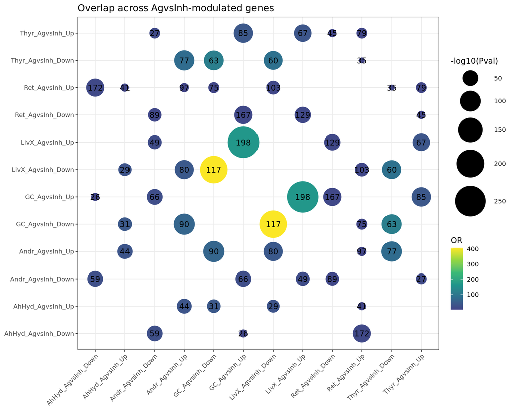

```r
Dot <- ggplot(ResSel, aes(DEGs, KBase, label=Numbers)) +
  geom_point(aes(size=-log10(Pval), col=OR)) +
  geom_text() +
  scale_size_continuous(range=c(2, 20), limits=c(2, round(-log10(min(ResSel$Pval)) + 0.5))) +
  scale_color_viridis_c(limits=c(1, round(max(ResSel$OR)+1)), begin=0.2) + xlab('') + ylab('') +
  theme_bw() +
  theme(axis.line = element_blank(), axis.title = element_blank(),
        axis.text.x = element_text(angle = 45, hjust = 1)) +
    ggtitle('Overlap across AgvsInh-modulated genes')

Dot
```

```r
ggsave(Dot, filename=paste0(OutputFolder, 'DotPlot_AgvsInh.pdf'), width=8, height=8)
```

## 7.3 Visualize overlap results selectively for retinoic, liverX, estrogen, thyroid

### Selection

```r
Path <- c('Thyr_AgvsInh_Up', 'Thyr_AgvsInh_Down', 'Ret_AgvsInh_Up', 'Ret_AgvsInh_Down',
          'Estr_AgvsInh_Up', 'Estr_AgvsInh_Down', 'LivX_AgvsInh_Up', 'LivX_AgvsInh_Down')
ResPath <- ResSel[ResSel$DEGs %in% Path & ResSel$KBase %in% Path, ]

ResPath
```

```
##                 DEGs             KBase        OR         Pval Numbers
## 1     Ret_AgvsInh_Up   Thyr_AgvsInh_Up  4.053005 1.421630e-18      79
## 2   Ret_AgvsInh_Down   Thyr_AgvsInh_Up  2.974483 8.726946e-09      45
## 5    LivX_AgvsInh_Up   Thyr_AgvsInh_Up 33.463606 6.733621e-66      67
## 6     Ret_AgvsInh_Up Thyr_AgvsInh_Down  2.012375 5.901433e-04      35
## 9  LivX_AgvsInh_Down Thyr_AgvsInh_Down 87.188923 3.444565e-79      60
## 10   Thyr_AgvsInh_Up    Ret_AgvsInh_Up  4.053005 1.421630e-18      79
## 11 Thyr_AgvsInh_Down    Ret_AgvsInh_Up  2.012375 5.901433e-04      35
## 14 LivX_AgvsInh_Down    Ret_AgvsInh_Up  6.739231 1.135165e-35     103
## 17   Thyr_AgvsInh_Up  Ret_AgvsInh_Down  2.974483 8.726946e-09      45
## 20   LivX_AgvsInh_Up  Ret_AgvsInh_Down  8.193473 1.435075e-55     129
## 41   Thyr_AgvsInh_Up   LivX_AgvsInh_Up 33.463606 6.733621e-66      67
## 42  Ret_AgvsInh_Down   LivX_AgvsInh_Up  8.193473 1.435075e-55     129
## 45 Thyr_AgvsInh_Down LivX_AgvsInh_Down 87.188923 3.444565e-79      60
## 46    Ret_AgvsInh_Up LivX_AgvsInh_Down  6.739231 1.135165e-35     103
```

### DotPlot: visualization

```r
ResPath <- dplyr::filter(ResPath, OR > 2) %>% dplyr::filter(Numbers > 25)
min(ResPath$Pval)
```

```
## [1] 3.444565e-79
```

```r
max(ResPath$OR)
```

```
## [1] 87.18892
```

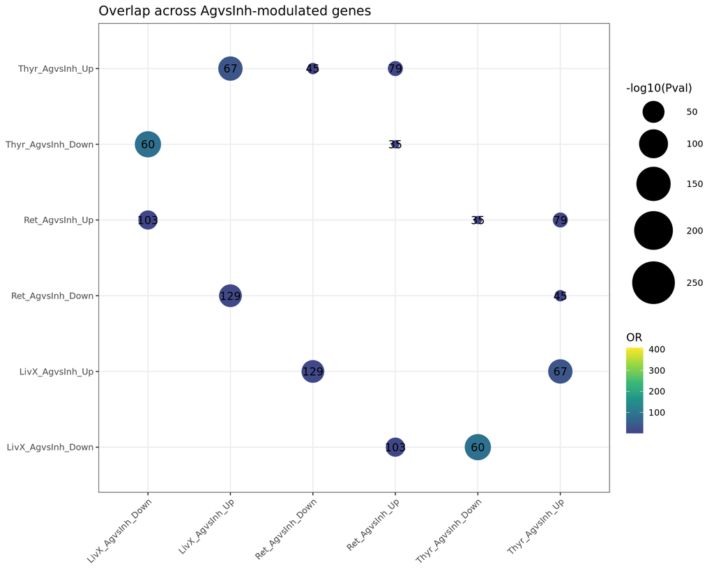

```r
Dot <- ggplot(ResPath, aes(DEGs, KBase, label=Numbers)) +
  geom_point(aes(size=-log10(Pval), col=OR)) +
  geom_text() +
  scale_size_continuous(range=c(2, 20), limits=c(2, round(-log10(min(ResSel$Pval)) + 0.5))) +
  scale_color_viridis_c(limits=c(1, round(max(ResSel$OR)+1)), begin=0.2) + xlab('') + ylab('') +
  theme_bw() +
  theme(axis.line = element_blank(), axis.title = element_blank(),
        axis.text.x = element_text(angle = 45, hjust = 1))+
  ggtitle('Overlap across AgvsInh-modulated genes')


Dot
```

```r
ggsave(Dot, filename=paste0(OutputFolder, 'DotPlot_AgvsInh_Selected.pdf'), width=8, height=8)
```

## 8. Session info

```r
SessionInfo <- sessionInfo()
Date <- date()
```

```r
Date
```

```
## [1] "Mon Jul 21 23:20:53 2025"
```

```r
SessionInfo
```